# Duplicated/ Repeated Cases in SISTRAT C1 (part 3)

18 junio, 2020

For the purpose of this page, we use the terms “rows” and “cases” as equal to refer to the entries of the dataset. In many of the processes made along the deduplication of entries in C1 dataset, we used unstandardized columns or many other data that was in fact duplicated by HASHs, that did not depend on events related to treatment.In order to find and delete duplicated data that does not add information relevant for the purposes of the study, we now may **use these standardized variables as a criteria to achieve the goal of having a unique event per HASH, by reducing its complexity based on irrelevant differences**.

As stated in the second part of the deduplication process, we need to consolidate and define separate treatments as blocks, by keeping information about each event’s complexities (such as referrals, changes of center, changes in plans and programs within each treatment), as variables of a single treatment. That is, to collapse intermediate events relative to a determined treatment into a single entry for each user. This will let us have a different treatment in every row.

### 1.Missing Dates of Discharge

In the previous deduplication stage, we only imputed the discharge dates of the cases that overlapped with other cases inside the database.

```r
#table(is.na(CONS_C1_df_dup_FEB_2020$fech_nac)) #para comprobar si se hizo l imputación de las fechas de nacimiento
library(dplyr)
library(data.table)
CONS_C1_df_dup_FEB_2020 %>% dplyr::filter(is.na(fech_egres_imp)) %>% janitor::tabyl(ano_bd) %>% dplyr::mutate(percent=scales::percent(percent)) %>%
    knitr::kable(format = "html", format.args = list(decimal.mark = ".", big.mark = ","),
               caption="Table 1. Missing Dates of Discharge by Year of the Dataset",
                 align =rep('c', 3),
               col.names = c("Year of Dataset", "Freq", "%")) %>%
   kableExtra::kable_styling(bootstrap_options = c("striped", "hover"),font_size = 10)
```

Table 1. Missing Dates of Discharge by Year of the Dataset

| Year of Dataset | Freq | % |
| --- | --- | --- |
| 2,010 | 11 | 0.135% |
| 2,011 | 63 | 0.776% |
| 2,012 | 10 | 0.123% |
| 2,013 | 23 | 0.283% |
| 2,014 | 15 | 0.185% |
| 2,015 | 23 | 0.283% |
| 2,016 | 55 | 0.677% |
| 2,017 | 59 | 0.727% |
| 2,018 | 122 | 1.503% |
| 2,019 | 7,738 | 95.307% |

### 2.Last User-Invariant Variables.

The last user-invariant variables had many different values by user. That is why it was necessary to use different sources to overcome ambiguities. Possibly, the process of formulating an answer is one of the factors that explains the ambiguity in the answers. Many times the respondents are not precise remembering specific ages. It is reasonable to think that those with a sustained substance abuse profile would experience difficulties to recall specific information.

- Age of Onset of Drug Use (edad_ini_cons) (n= 40,627), had too many distinct values by each user (n 15,253.
- Age of Onset of Drug Use Primary Substance (edad_ini_sus_prin) (n= 41,794), had too many distinct values by each user (n= 15,800).

First, we discarded cases with ages of onset of drug use that were posterior to the age at admission (n= 58). We also did the same for the invalid ages of onset of primary drug use (n= 210).

```r
CONS_C1_df_dup_FEB_2020 %>%
  dplyr::mutate(edad_ini_cons=case_when(edad_al_ing<=edad_ini_cons~NA_integer_,TRUE~as.integer(edad_ini_cons)))%>% #may 2010= filtro por aquellos casos que son invalidos, para descartarlos
  dplyr::mutate(edad_ini_sus_prin=case_when(edad_al_ing<=edad_ini_sus_prin~NA_integer_,TRUE~as.integer(edad_ini_sus_prin)))%>% #may 2010= filtro por aquellos casos que son invalidos, para descartarlos
  dplyr::mutate(edad_ini_sus_prin=case_when(edad_ini_sus_prin<edad_ini_cons~NA_integer_,TRUE~as.integer(edad_ini_sus_prin)))%>%

assign("CONS_C1_df_dup_MAY_2020_prev0",., envir = .GlobalEnv)
```

The following table shows the amount of ages that varies within each user.

```r
prueba_edad_ini_cons <- CONS_C1_df_dup_MAY_2020_prev0 %>% group_by(hash_key) %>% dplyr::mutate(edad_ini_cons_por_hash=n_distinct(edad_ini_cons)) %>% ungroup() %>% dplyr::filter(edad_ini_cons_por_hash>1) %>% dplyr::distinct(hash_key)

prueba_edad_ini_sus_prin <- CONS_C1_df_dup_MAY_2020_prev0 %>% group_by(hash_key) %>% dplyr::mutate(edad_ini_sus_prin_por_hash=n_distinct(edad_ini_sus_prin)) %>% ungroup() %>% dplyr::filter(edad_ini_sus_prin_por_hash>1) %>% dplyr::distinct(hash_key)

edad_ini_cons_summ<-
  CONS_C1_df_dup_MAY_2020_prev0 %>%
   dplyr::filter(hash_key %in% as.character(as.vector(unlist(as.data.table(unlist(prueba_edad_ini_cons)))))) %>%
    group_by(hash_key) %>%
  dplyr::add_tally() %>%
   summarise(n=mean(n), edad_ini_cons_p25 = quantile(edad_ini_cons, c(0.25),na.rm=T),edad_ini_cons_p50 = quantile(edad_ini_cons, c(0.50),na.rm=T),edad_ini_cons_p75 = quantile(edad_ini_cons, c(0.75),na.rm=T),edad_ini_conssd=sd(edad_ini_cons,na.rm=T), min=min(edad_ini_cons, na.rm = T),max=max(edad_ini_cons, na.rm = T),mean=mean(edad_ini_cons,na.rm=T),ranges=abs(max-min)) %>%
    ungroup()%>%
  dplyr::mutate(diff_p25_p50=abs(edad_ini_cons_p50-edad_ini_cons_p25),diff_p75_p50=abs(edad_ini_cons_p50-edad_ini_cons_p75),min_mean=abs(min-mean), max_mean=abs(max-mean))%>%
    summarise(avg_n=mean(n), sd_n=sd(n),avg_p25_p50=mean(diff_p25_p50),avg_p75_p50=mean(diff_p75_p50),avg_sd=mean(edad_ini_conssd,na.rm=T),avg_min_mean=mean(min_mean,na.rm=T),avg_max_mean=mean(max_mean,na.rm=T),avg_ranges=mean(ranges,na.rm=T),sd_ranges=sd(ranges,na.rm=T),p75_ranges=quantile(ranges, c(0.75),na.rm=T),p90_ranges=quantile(ranges, c(0.90),na.rm=T)) %>%
  round(2)
edad_ini_sus_prin_summ<-
  CONS_C1_df_dup_MAY_2020_prev0 %>%
   dplyr::filter(hash_key %in% as.character(as.vector(unlist(as.data.table(unlist(prueba_edad_ini_sus_prin)))))) %>%
    group_by(hash_key) %>%
    dplyr::add_tally() %>%
   summarise(n=mean(n),edad_ini_sus_prin_p25 = quantile(edad_ini_sus_prin, c(0.25),na.rm=T),edad_ini_sus_prin_p50 = quantile(edad_ini_sus_prin, c(0.50),na.rm=T),edad_ini_sus_prin_p75 = quantile(edad_ini_sus_prin, c(0.75),na.rm=T),edad_ini_sus_prinsd=sd(edad_ini_sus_prin,na.rm=T), min=min(edad_ini_sus_prin, na.rm = T),max=max(edad_ini_sus_prin, na.rm = T),mean=mean(edad_ini_sus_prin,na.rm=T),ranges=abs(max-min)) %>%
    ungroup()%>%
    dplyr::mutate(diff_p25_p50=abs(edad_ini_sus_prin_p50-edad_ini_sus_prin_p25),diff_p75_p50=abs(edad_ini_sus_prin_p50-edad_ini_sus_prin_p75),min_mean=abs(min-mean), max_mean=abs(max-mean))%>%
    summarise(avg_n=mean(n), sd_n=sd(n),avg_p25_p50=mean(diff_p25_p50),avg_p75_p50=mean(diff_p75_p50),avg_sd=mean(edad_ini_sus_prinsd,na.rm=T),avg_min_mean=mean(min_mean,na.rm=T),avg_max_mean=mean(max_mean,na.rm=T),avg_ranges=mean(ranges,na.rm=T),sd_ranges=sd(ranges,na.rm=T),p75_ranges=quantile(ranges, c(0.75),na.rm=T),p90_ranges=quantile(ranges, c(0.90),na.rm=T)) %>%
  round(2)
rbind(cbind(Variable="Age of Onset of Drug Use",round(edad_ini_cons_summ,2)),cbind(Variable="Age of Onset of Drug Use Primary Substance",round(edad_ini_sus_prin_summ,2))) %>%
    knitr::kable(format = "html", format.args = list(decimal.mark = ".", big.mark = ","),
               caption="Table 2. Distribution of Differences in Years Within Users",
                 align =rep('c', 101),
               col.names = c("Variables","Avg. Cases per User", "Std.Dev. Cases per User","Avg. Diff. Perc 25-50", "Avg. Diff. Perc 75-50","Avg. Std.Dev","Avg. Diff. Min-Mean","Avg. Diff. Max-Mean","Avg. Range", "Std.Dev. Range","Perc 75 Range","Perc 90 Range"))  %>%
   kableExtra::kable_styling(bootstrap_options = c("striped", "hover"),font_size =10) %>%
  kableExtra::scroll_box(width = "100%", height = "250px")
```

Table 2. Distribution of Differences in Years Within Users

| Variables | Avg. Cases per User | Std.Dev. Cases per User | Avg. Diff. Perc 25-50 | Avg. Diff. Perc 75-50 | Avg. Std.Dev | Avg. Diff. Min-Mean | Avg. Diff. Max-Mean | Avg. Range | Std.Dev. Range | Perc 75 Range | Perc 90 Range |
| --- | --- | --- | --- | --- | --- | --- | --- | --- | --- | --- | --- |
| Age of Onset of Drug Use | 2.66 | 1.06 | 0.86 | 0.96 | 2.63 | 1.82 | 1.93 | 3.75 | 4.96 | 4 | 9 |
| Age of Onset of Drug Use Primary Substance | 2.64 | 1.05 | 1.43 | 1.45 | 3.69 | 2.95 | 2.95 | 5.91 | 6.24 | 8 | 14 |

Considering the abovementioned, we decided to restrict the rules to obtain unique values in user-invariant variables by each user, to the 25% of users that had more considerable variability in each value of the registries present in the dataset.

```r
knitr::include_graphics("G:/Mi unidad/Alvacast/SISTRAT 2019 (github)/SUD_CL/Figures/same_hash_distinct_values_user_invariant_top.svg")
```

[figure not shown]

Figure 1. Decision Tree for the Users with more than one value in a User-Invariant Variable

In case of Age of Onset of Drug Use (edad_ini_cons), users that had Age of Onset of Drug Use (edad_ini_cons) greater than 4.

```r
knitr::include_graphics("G:/Mi unidad/Alvacast/SISTRAT 2019 (github)/SUD_CL/Figures/age_onset_drug_use_same_hash_distinct_values_user_invariant.svg")
```

[figure not shown]

```r
CONS_C1_df_dup_MAY_2020_prev0_edad_ini_cons <- CONS_C1_df_dup_MAY_2020_prev0 %>% group_by(hash_key) %>% dplyr::mutate(edad_ini_cons_por_hash=n_distinct(edad_ini_cons)) %>% ungroup() %>% dplyr::filter(edad_ini_cons_por_hash>1) %>% dplyr::distinct(hash_key)
CONS_C1_df_dup_FEB_2020 %>%
 dplyr::filter(hash_key %in% as.character(as.vector(unlist(as.data.table(unlist(CONS_C1_df_dup_MAY_2020_prev0_edad_ini_cons)))))) %>% # Select HASHs of cited cases
 dplyr::arrange(hash_key) %>% #ordeno por ids
dplyr::select(row, hash_key, ano_bd, edad_ini_cons, edad, fech_nac,edad_al_ing, fech_ing, fech_egres_imp, tipo_de_plan, senda)%>%
    head(40)%>%
    knitr::kable(format = "html", format.args = list(decimal.mark = ".", big.mark = ","),
               caption="Table 3. HASHs with more than one Age of Onset of Drug Use (First 40 Cases)",
                 align =rep('c', 101))  %>%
   kableExtra::kable_styling(bootstrap_options = c("striped", "hover"),font_size = 8) %>%
  kableExtra::scroll_box(width = "100%", height = "375px")
```

Table 3. HASHs with more than one Age of Onset of Drug Use (First 40 Cases)

| row | hash_key | ano_bd | edad_ini_cons | edad | fech_nac | edad_al_ing | fech_ing | fech_egres_imp | tipo_de_plan | senda |
| --- | --- | --- | --- | --- | --- | --- | --- | --- | --- | --- |
| 157,456 | 00012586ea3036b7a18093c396847a87 | 2,019 | 15 | 42 | 1977-11-12 | 41.47023 | 2019-05-03 | NA | PG-PAI | Si |
| 53,084 | 00012586ea3036b7a18093c396847a87 | 2,014 | 13 | 42 | 1977-11-12 | 36.15606 | 2014-01-08 | 2014-11-03 | PG-PR | No |
| 120,237 | 0007678b8b35fa0961d1e8110fbf9620 | 2,017 | 15 | 31 | 1988-03-08 | 29.39904 | 2017-08-01 | 2017-09-19 | M-PR | Si |
| 117,796 | 0007678b8b35fa0961d1e8110fbf9620 | 2,017 | 15 | 31 | 1988-03-08 | 29.23203 | 2017-06-01 | 2017-07-05 | M-PR | No |
| 109,116 | 0007678b8b35fa0961d1e8110fbf9620 | 2,017 | 19 | 31 | 1988-03-08 | 28.49555 | 2016-09-05 | 2017-05-29 | PG-PAI | Si |
| 21,420 | 000abb62b93e12b04ad68c69e37597a6 | 2,012 | 14 | 37 | 1982-10-25 | 28.51745 | 2011-05-02 | 2012-03-19 | PG-PAI | Si |
| 2,859 | 000abb62b93e12b04ad68c69e37597a6 | 2,010 | NA | 37 | 1982-10-25 | 25.66735 | 2008-06-25 | 2010-06-23 | PG-PAI | Si |
| 57,760 | 000ec7b631988f81f3fc07f4de6cb9a9 | 2,014 | 15 | 39 | 1980-06-14 | 33.93566 | 2014-05-22 | 2014-07-24 | PG-PAI | Si |
| 52,499 | 000ec7b631988f81f3fc07f4de6cb9a9 | 2,014 | 16 | 39 | 1980-06-14 | 33.48939 | 2013-12-10 | 2014-02-28 | PG-PAB | Si |
| 36,044 | 000ec7b631988f81f3fc07f4de6cb9a9 | 2,013 | 15 | 39 | 1980-06-14 | 32.58590 | 2013-01-14 | 2013-11-28 | PG-PAI | Si |
| 90,698 | 000ff5e2fdd25462e4febeb6a9099bec | 2,016 | 14 | 50 | 1969-05-16 | 46.46954 | 2015-11-04 | 2016-09-14 | PG-PR | Si |
| 19,994 | 000ff5e2fdd25462e4febeb6a9099bec | 2,011 | 12 | 50 | 1969-05-16 | 42.51061 | 2011-11-19 | 2012-01-31 | PG-PAI | Si |
| 29,383 | 001022ffb28057b24dd76900bbf1e3de | 2,012 | 14 | 37 | 1982-04-20 | 30.25873 | 2012-07-23 | 2012-11-02 | M-PR | Si |
| 16,163 | 001022ffb28057b24dd76900bbf1e3de | 2,011 | 15 | 37 | 1982-04-20 | 29.10062 | 2011-05-27 | 2011-10-10 | PG-PAI | Si |
| 162,840 | 0012beab59a3a84eec95c9371f393a06 | 2,019 | 15 | 27 | 1991-11-26 | 27.76728 | 2019-09-02 | NA | PG-PAB | Si |
| 156,952 | 0012beab59a3a84eec95c9371f393a06 | 2,019 | 14 | 27 | 1991-11-26 | 27.48802 | 2019-05-23 | 2019-08-29 | PG-PR | Si |
| 123,290 | 001844aad3a5ef098c4c1d5e479ccbd6 | 2,017 | 14 | 37 | 1982-02-12 | 35.64134 | 2017-10-04 | 2017-12-01 | PG-PAB | Si |
| 86,678 | 001844aad3a5ef098c4c1d5e479ccbd6 | 2,016 | 15 | 37 | 1982-02-12 | 33.09240 | 2015-03-18 | 2016-12-20 | M-PR | Si |
| 66,251 | 001844aad3a5ef098c4c1d5e479ccbd6 | 2,015 | 15 | 37 | 1982-02-12 | 31.89049 | 2014-01-03 | 2015-03-16 | M-PAI | Si |
| 92,601 | 001b0ff241cd0d95828b86b4bdab8c19 | 2,016 | 20 | 52 | 1967-06-30 | 48.54209 | 2016-01-14 | 2016-05-12 | PG-PR | Si |
| 37,992 | 001b0ff241cd0d95828b86b4bdab8c19 | 2,013 | 18 | 52 | 1967-06-30 | 45.74127 | 2013-03-27 | 2013-06-28 | PG-PAI | Si |
| 31,481 | 001b0ff241cd0d95828b86b4bdab8c19 | 2,012 | 17 | 52 | 1967-06-30 | 45.34155 | 2012-11-01 | 2013-01-02 | PG-PAB | Si |
| 73,339 | 001ba6dfc8332930f9d9d20a0fa6685b | 2,015 | 14 | 26 | 1993-06-28 | 21.60712 | 2015-02-05 | 2015-03-24 | PG-PAI | No |
| 44,192 | 001ba6dfc8332930f9d9d20a0fa6685b | 2,013 | 13 | 26 | 1993-06-28 | 20.22177 | 2013-09-17 | 2013-09-30 | PG-PR | Si |
| 36,728 | 001ba6dfc8332930f9d9d20a0fa6685b | 2,013 | 13 | 26 | 1993-06-28 | 19.61123 | 2013-02-06 | 2013-03-20 | PG-PR | Si |
| 139,264 | 001fb4d82755ca201c292fe318fef341 | 2,018 | 15 | 55 | 1963-12-14 | 54.51608 | 2018-06-20 | 2018-10-19 | PG-PR | Si |
| 32,645 | 001fb4d82755ca201c292fe318fef341 | 2,013 | 18 | 55 | 1963-12-14 | 48.09309 | 2012-01-17 | 2013-08-27 | PG-PAI | Si |
| 35,823 | 00227e8787d1ce564dae87621440d48b | 2,013 | 14 | 45 | 1974-10-18 | 38.22861 | 2013-01-09 | 2013-11-01 | M-PAI | Si |
| 32,399 | 00227e8787d1ce564dae87621440d48b | 2,013 | 15 | 45 | 1974-10-18 | 37.23203 | 2012-01-11 | 2013-01-04 | PG-PAI | Si |
| 4,824 | 00227e8787d1ce564dae87621440d48b | 2,010 | NA | 45 | 1974-10-18 | 35.52635 | 2010-04-28 | 2010-08-10 | PG-PAI | Si |
| 72,657 | 00237788c4c803c12fecac82105ea4f0 | 2,015 | 13 | 37 | 1982-08-26 | 32.43806 | 2015-02-02 | 2015-09-23 | PG-PAI | Si |
| 46,208 | 00237788c4c803c12fecac82105ea4f0 | 2,013 | 14 | 37 | 1982-08-26 | 31.21424 | 2013-11-12 | 2014-02-26 | PG-PAB | Si |
| 139,158 | 002a54a1864024540089017666091fc0 | 2,018 | 27 | 39 | 1980-10-31 | 37.65366 | 2018-06-27 | 2018-11-23 | PG-PR | Si |
| 10,890 | 002a54a1864024540089017666091fc0 | 2,011 | NA | 39 | 1980-10-31 | 29.67830 | 2010-07-06 | 2011-03-31 | PG-PAB | Si |
| 122,564 | 002b4df919e2b1cc6ff0cdb26b27a514 | 2,017 | 14 | 36 | 1983-09-23 | 34.00684 | 2017-09-25 | 2017-12-15 | PG-PAI | Si |
| 76,859 | 002b4df919e2b1cc6ff0cdb26b27a514 | 2,015 | 15 | 36 | 1983-09-23 | 31.67693 | 2015-05-28 | 2015-11-27 | PG-PAB | Si |
| 34,105 | 002c979e254773f17812d9bff13996dc | 2,013 | 16 | 35 | 1983-12-05 | 28.85147 | 2012-10-11 | 2013-01-04 | PG-PAB | Si |
| 4,271 | 002c979e254773f17812d9bff13996dc | 2,010 | NA | 35 | 1983-12-05 | 26.28337 | 2010-03-18 | 2010-05-31 | PG-PAI | Si |
| 158,646 | 00335a6165270de0986718e354c20dcb | 2,019 | 12 | 58 | 1961-08-05 | 57.86995 | 2019-06-19 | 2019-07-17 | PG-PR | Si |
| 156,853 | 00335a6165270de0986718e354c20dcb | 2,019 | 15 | 58 | 1961-08-05 | 57.76865 | 2019-05-13 | 2019-06-14 | PG-PAI | Si |

```r
#edad_ini_cons_summ[,"p75_ranges"]
#edad_ini_cons_summ[,"p90_diff_p75_p50"]

#invisible(
  #CONS_C1_df_dup_MAY_2020_prev%>%
#    edad_ini_cons_lo_75%>%
#  dplyr::filter(hash_key %in% c("014168e096787bf7e4c6951a3b4c27de","0110bb39c8fffafe0bbbe1fd17f51e71")) %>%
#  dplyr::select(row, hash_key, obs)

#      edad_ini_cons_lo_75%>%
#  dplyr::filter(hash_key %in% c("014168e096787bf7e4c6951a3b4c27de","0110bb39c8fffafe0bbbe1fd17f51e71"))
#
##  data.frame(hash_key=edad_ini_cons_up_75)%>%
#  dplyr::filter(hash_key %in% c("014168e096787bf7e4c6951a3b4c27de","0110bb39c8fffafe0bbbe1fd17f51e71"))
#)

###PARA HACER LA CONVERSION
#_______________________

edad_ini_cons_up_75<-
    as.character(
      CONS_C1_df_dup_MAY_2020_prev0 %>%
    dplyr::filter(hash_key %in% as.character(as.vector(unlist(as.data.table(unlist(CONS_C1_df_dup_MAY_2020_prev0_edad_ini_cons)))))) %>%
    dplyr::group_by(hash_key) %>%
    dplyr::mutate(range=abs(max(edad_ini_cons,na.rm=T)-abs(min(edad_ini_cons,na.rm=T)))) %>%
    dplyr::filter(range>as.numeric(edad_ini_cons_summ[,"p75_ranges"]))%>%
    #dplyr::select(hash_key, range)
    distinct(hash_key)%>%
    unlist())

##BAJO EL PERCENTIL 75, SE REEMPLAZA CON LA MEDIA
edad_ini_cons_lo_75<-
    CONS_C1_df_dup_MAY_2020_prev0 %>%
    dplyr::filter(hash_key %in% as.character(as.vector(unlist(as.data.table(unlist(CONS_C1_df_dup_MAY_2020_prev0_edad_ini_cons)))))) %>%
    dplyr::group_by(hash_key) %>%
    dplyr::mutate(mean_edad_ini_cons_lo75=round(mean(edad_ini_cons,na.rm=T),0),range=abs(max(edad_ini_cons,na.rm=T)-abs(min(edad_ini_cons,na.rm=T)))) %>%
    dplyr::ungroup()%>%
    dplyr::filter(range<=as.numeric(edad_ini_cons_summ[,"p75_ranges"]))%>%
    dplyr::select(hash_key,mean_edad_ini_cons_lo75)%>%
    dplyr::distinct(hash_key,.keep_all=T)


##VER el resumen de los casos
#CONS_C1_df_dup_MAY_2020_prev0 %>% dplyr::filter(hash_key %in% as.character(unlist(CONS_C1_df_dup_MAY_2020_prev0_edad_ini_cons[,"hash_key"]))) %>% group_by(hash_key)%>% print()
#<- CONS_C1_df_dup_MAY_2020_prev0 %>% dplyr::filter(hash_key %in% edad_ini_cons_up_75) %>% dplyr::group_by(hash_key) %>% dplyr::add_tally(name="n_edad_ini_cons_sus") %>% dplyr::mutate(n_dis=n_distinct(ano_bd)) %>% dplyr::ungroup() %>% dplyr::filter(n_dis>1)%>% distinct(hash_key)%>% unlist()%>% as.character()

#_#_#_#_#_#_#_#_#_#_#_#_#_#_#_#_#_#_#_#_#_#_#_#_#_#_#_#_#_#_#_#_#_#_#_#_#_#_#_#_#_#_#_#_#_#_#_#_#_#_#_#_#_#_#_#_#_#_#_#_#_#_#_#_#_#_#_#_#_#_#_#_#_#_#_#_#_#_#_#_#_#_#_#_#_#_#_#_#_#_
#_______________________
###PARA HACER LA CONVERSION en los mayores al 75 (edad_ini_cons_great_75)
#_______________________

#_#_#_#_#_#_
#1. distinta edad, bd tratamiento más reciente- Dejar la fecha del tratamiento más reciente
#proviene de más de una base de datos anual
CONS_C1_df_dup_MAY_2020_prev0 %>%
dplyr::filter(hash_key %in% edad_ini_cons_up_75) %>%
dplyr::group_by(hash_key) %>%
dplyr::add_tally(name="n_edad_ini_cons_sus") %>%
dplyr::mutate(n_dis=n_distinct(ano_bd)) %>%
dplyr::ungroup() %>%
dplyr::filter(n_dis>1,!is.na(edad_ini_cons)) %>%
dplyr::arrange(hash_key,desc(ano_bd)) %>% #may 2020, agregué descendiente la edad, de más reciente a más antiguo
dplyr::select(row, hash_key, ano_bd, edad_ini_cons, edad, fech_nac,edad_al_ing,n_edad_ini_cons_sus)%>%
dplyr::group_by(hash_key)%>%
dplyr::mutate(max_ano=max(ano_bd))%>%
#dplyr::slice(which.max(ano_bd)) %>% #MAY 2020, dejé como un procedimiento de APR 2020
dplyr::filter(max_ano==ano_bd) %>%
dplyr::ungroup()%>%
assign("hash_edad_ini_cons_most_recent_db",., envir = .GlobalEnv) %>% #APR 2020= 3,416 casos // #MAY 2020= 3,931 (3,416 usuarios)
 dplyr::group_by(hash_key)%>%
  distinct(edad_ini_cons,.keep_all=T)%>%
  dplyr::mutate(n_dis=n_distinct(edad_ini_cons)) %>%
  dplyr::filter(n_dis>1)%>% #45
  dplyr::mutate(edad_ini_cons_=paste0("edad_ini_cons_",row_number()))%>%
  tidyr::pivot_wider(id_cols =hash_key,names_from = edad_ini_cons_, values_from = edad_ini_cons,names_repair="minimal",values_fill = list(n = ""))%>%
  dplyr::rename("edad_ini_cons"="edad_ini_cons_1")%>%
  assign("hash_edad_ini_cons_most_recent_db_more_one_value_1b",., envir = .GlobalEnv) #1,268 casos de 625 HASHs

hash_edad_ini_cons_most_recent_db_1a <- hash_edad_ini_cons_most_recent_db%>%  #3,031
  dplyr::select(-n_edad_ini_cons_sus)%>%
    group_by(hash_key)%>%
    distinct(edad_ini_cons,.keep_all=T)%>%
    dplyr::mutate(n_dis=n_distinct(edad_ini_cons)) %>%
    dplyr::filter(n_dis==1) %>%
      ungroup()%>%
    dplyr::select(-n_dis,-row,-ano_bd,-max_ano)

#_#_#_#_#_#_
#_#_#_#_#_#_
#2a. distinta edad, misma bd tratamiento, más de 2 casos- Dejar la fecha del tratamiento más frecuente
#misma edad base de datos por año, pero más de 2 casos ---> valor + frecuente
CONS_C1_df_dup_MAY_2020_prev0 %>%
dplyr::filter(hash_key %in% edad_ini_cons_up_75) %>%
dplyr::group_by(hash_key) %>%
dplyr::add_tally() %>%
dplyr::mutate(n_dis=n_distinct(ano_bd)) %>%
dplyr::ungroup() %>%
dplyr::filter(n_dis==1,n>2) %>% #más de 2 hash, pero todos dentro de la misma bd del mismo año
dplyr::select(-n) %>%
dplyr::filter(!is.na(edad_ini_cons))%>%
dplyr::mutate(concat_hash_edadinicons=paste0(hash_key,"_",edad_ini_cons)) %>%
dplyr::group_by(concat_hash_edadinicons) %>%
dplyr::add_tally() %>%  #agrego un nuevo n, para contar los distintos nacionalidades
dplyr::ungroup() %>%
dplyr::select(row, hash_key, ano_bd, edad_ini_cons, edad, fech_nac,edad_al_ing,n)%>%
dplyr::group_by(hash_key) %>%
#dplyr::slice(which.max(n)) %>% #me quedo con la concatenación por hash key que más se repite.
dplyr::top_n(n)%>%
dplyr::rename("cases_by_concat_hash_edad_ini_cons"="n")%>%
dplyr::ungroup() %>%
assign("hash_edad_ini_cons_most_freq_value",., envir = .GlobalEnv)%>% # APR 2020= 43 casos // MAY 2020, 99 casos, 43 usuarios.
dplyr::select(-cases_by_concat_hash_edad_ini_cons)%>%
group_by(hash_key)%>%
add_tally()%>%
dplyr::filter(n>1)%>% #99 casos
dplyr::mutate(edad_ini_cons_=paste0("edad_ini_cons_",row_number()))%>%
tidyr::pivot_wider(id_cols =hash_key,names_from = edad_ini_cons_, values_from = edad_ini_cons,names_repair="minimal",values_fill = list(n = ""))%>%
dplyr::rename("edad_ini_cons"="edad_ini_cons_1")%>%
assign("hash_sus_ini_most_freq_value_more_one_value_2a2",., envir = .GlobalEnv) #136
```

```r
#seleccionar los casos en que en la misma base de datos hay sólo un caso que es mayor
hash_edad_ini_cons_most_freq_value_2a1 <- hash_edad_ini_cons_most_freq_value%>%
  dplyr::select(-cases_by_concat_hash_edad_ini_cons)%>%
    group_by(hash_key)%>%
    add_tally()%>%
    dplyr::filter(n==1) %>%
    dplyr::select(-n, -row, -ano_bd)

#_#_#_#_#_#_
#_#_#_#_#_#_
#2b. distinta edad, misma bd tratamiento, más de 2 casos- Dejar la fecha del tratamiento más frecuente. Casos con fecha de trat + reciente
CONS_C1_df_dup_MAY_2020_prev0 %>%
  dplyr::filter(hash_key %in% as.character(unlist(hash_edad_ini_cons_most_recent_db_more_one_value_1b["hash_key"])))%>%
  dplyr::group_by(hash_key,edad_ini_cons) %>%
  dplyr::add_tally(name="n_por_hash_edad_ini_cons") %>%
  dplyr::ungroup()%>%
  dplyr::filter(!is.na(edad_ini_cons))%>%
  dplyr::group_by(hash_key) %>%
  dplyr::add_tally(name="n_por_hash") %>%
  dplyr::arrange(desc(n_por_hash_edad_ini_cons))%>%
  #  dplyr::ungroup()%>%
  dplyr::top_n(1,n_por_hash_edad_ini_cons)%>%
  dplyr::arrange(desc(n_por_hash),hash_key)%>%
  dplyr::distinct(hash_key,edad_ini_cons,.keep_all=T)%>%
  dplyr::select(row, hash_key, ano_bd, edad_ini_cons,edad_al_ing, n_por_hash,n_por_hash_edad_ini_cons) %>%
  dplyr::group_by(hash_key)%>%
  dplyr::add_tally(name="n_por_hash_edad_ini_cons") %>%
  assign("hash_edad_ini_cons_most_recent_db_more_one_value_mfv_2b",., envir = .GlobalEnv)

hash_edad_ini_cons_most_recent_db_more_one_value_mfv_2b %>%
  dplyr::filter(n_por_hash_edad_ini_cons>1)%>% #45
  dplyr::mutate(edad_ini_cons_=paste0("edad_ini_cons_",row_number()))%>%
  tidyr::pivot_wider(id_cols =hash_key,names_from = edad_ini_cons_, values_from = edad_ini_cons,names_repair="minimal",values_fill = list(n = ""))%>%
  dplyr::rename("edad_ini_cons"="edad_ini_cons_1")%>%
  assign("hash_edad_ini_cons_most_recent_db_more_one_value__mfv_more_one_value_2b2",., envir = .GlobalEnv)

hash_edad_ini_cons_most_recent_db_more_one_value_mfv_2b1<-
  hash_edad_ini_cons_most_recent_db_more_one_value_mfv_2b%>%
  dplyr::filter(n_por_hash_edad_ini_cons==1)%>%
  dplyr::select(hash_key,edad_ini_cons)

#_#_#_#_#_#_
#_#_#_#_#_#_
# 3. Sólo 2 casos . fechas de nacimiento, en la misma base de datos anual.
#misma edad base de datos por año, pero sólo 2 casos ---> se obtiene la media
#Actualizar a mayo

CONS_C1_df_dup_MAY_2020_prev0 %>%
dplyr::filter(hash_key %in% edad_ini_cons_up_75) %>%
dplyr::group_by(hash_key) %>%
dplyr::add_tally() %>%
dplyr::mutate(n_dis=n_distinct(ano_bd)) %>%
dplyr::ungroup() %>%
dplyr::filter(n_dis==1,n==2) %>% #casos en que hay que recurrir a otras variables
dplyr::arrange(hash_key) %>%
 dplyr::select(row, hash_key, ano_bd, edad_ini_cons, edad, fech_nac,edad_al_ing)%>%
  dplyr::group_by(hash_key) %>%
    dplyr::mutate(rn=row_number()) %>%
  as.data.frame() %>%
  reshape(idvar = "hash_key", timevar = "rn", direction = "wide") %>%
  dplyr::mutate(mean_edad_ini_cons=round(rowMeans(cbind(edad_ini_cons.1,edad_ini_cons.2), na.rm=T),0)) %>%
dplyr::select(hash_key,mean_edad_ini_cons) %>%
  assign("edad_ini_cons_misma_bd_2_casos_3",., envir = .GlobalEnv)

invisible(
CONS_C1_df_dup_MAY_2020_prev0 %>%
    dplyr::filter(hash_key %in% as.character(as.vector(unlist(as.data.table(unlist(edad_ini_cons_misma_bd_2_casos_3[,"hash_key"])))))) %>%
          dplyr::filter(hash_key %in% c("014168e096787bf7e4c6951a3b4c27de","0110bb39c8fffafe0bbbe1fd17f51e71"))%>%
    dplyr::select(hash_key,ano_bd,edad_ini_cons,obs)
)
#_#_#_#_#_#_#_#_#_#_#_#_#_#_#_#_#_#_

#CONS_C1_df_dup_MAY_2020_prev0 %>% dplyr::filter(hash_key %in% edad_ini_cons_up_75) %>% group_by(hash_key)%>% print()
#CONS_C1_df_dup_MAY_2020_prev0 %>%
#dplyr::filter(hash_key %in% as.character(unlist(hash_sus_ini_most_freq_value_more_one_value_2a2[,"hash_key"]))) %>% group_by(hash_key)%>% print()
#CONS_C1_df_dup_MAY_2020_prev0 %>%
#dplyr::filter(hash_key %in% as.character(unlist(hash_edad_ini_cons_most_recent_db_1a[,"hash_key"]))) %>% group_by(hash_key)%>% print()
#CONS_C1_df_dup_MAY_2020_prev0 %>% dplyr::filter(hash_key %in% as.character(unlist(hash_edad_ini_cons_most_recent_db_more_one_value_1b[,"hash_key"]))) %>% group_by(hash_key)%>% print()
#CONS_C1_df_dup_MAY_2020_prev0 %>% dplyr::filter(hash_key %in% as.character(unlist(hash_edad_ini_cons_most_recent_db_more_one_value_mfv_2b1[,"hash_key"]))) %>% group_by(hash_key)%>% print()
#CONS_C1_df_dup_MAY_2020_prev0 %>% dplyr::filter(hash_key %in% as.character(unlist(hash_edad_ini_cons_most_recent_db_more_one_value__mfv_more_one_value_2b2[,"hash_key"]))) %>% group_by(hash_key)%>% print()
#CONS_C1_df_dup_MAY_2020_prev0 %>% dplyr::filter(hash_key %in% as.character(unlist(hash_edad_ini_cons_most_recent_db_more_one_value__mfv_more_one_value_2b2[,"hash_key"]))) %>% group_by(hash_key)%>% print()

#_#_#_#_#_#_#_#_#_#_#_#_#_#_#_#_#_#_#_#_#_#_#_#_#_#_#_#_#_#_#_#_#_#_#_#_#_#_#_#_#_#_#_#_#_#_#_#_#_#_#_#_#_#_#_#_#_#_#_#_
#_#_#_#_#_#_#_#_#_#_#_#_#_#_#_#_#_#_#_#_#_#_#_#_#_#_#_#_#_#_#_#_#_#_#_#_#_#_#_#_#_#_#_#_#_#_#_#_#_#_#_#_#_#_#_#_#_#_#_#_
invisible(c("Manual Review"))

invisible(
CONS_C1_df_dup_MAY_2020_prev0 %>%
dplyr::filter(hash_key %in% c(as.character(unlist(edad_ini_cons_misma_bd_2_casos_3[,"hash_key"])),
                              as.character(unlist(hash_sus_ini_most_freq_value_more_one_value_2a2[,"hash_key"])),
                              as.character(unlist(hash_edad_ini_cons_most_recent_db_more_one_value__mfv_more_one_value_2b2[,"hash_key"]))))%>%
    dplyr::arrange(hash_key)%>%
    dplyr::filter(!is.na(edad_ini_cons))%>%
    dplyr::select(hash_key, ano_bd,edad_al_ing, edad_inicio_consumo,edad_ini_cons, edad_inicio_sustancia_principal, edad_ini_sus_prin)
#1480
)

casos_fecha_inicio_cons_sus_empates_3 <-
  CONS_C1_df_dup_MAY_2020_prev0 %>%
  dplyr::filter(hash_key %in% c(as.character(unlist(edad_ini_cons_misma_bd_2_casos_3[,"hash_key"])),
                              as.character(unlist(hash_sus_ini_most_freq_value_more_one_value_2a2[,"hash_key"])),
                              as.character(unlist(hash_edad_ini_cons_most_recent_db_more_one_value__mfv_more_one_value_2b2[,"hash_key"]))))%>%
  dplyr::filter(!is.na(edad_ini_cons))%>%
  group_by(hash_key) %>%
  summarise(mean_edad_ini_cons=round(mean(edad_ini_cons,na.rm=T),0))
```

```r
#CONS_C1_df_dup_MAY_2020_prev0 %>% dplyr::filter(hash_key %in% as.character(unlist(casos_con_fechas_invalidas_por_fecha_inicio_cons_sus_prin_2_casos_3a[,"hash_key"])))%>% group_by(hash_key)

#CONS_C1_df_dup_MAY_2020_prev0 %>% dplyr::filter(hash_key %in% as.character(unlist(casos_con_fechas_invalidas_por_fecha_inicio_cons_sus_prin_2_casos_3a[,"hash_key"])))%>% group_by(hash_key)

#_#_#_#_#_#_#_#_#_#_#_#_#_#_#_#_#_#_#_#_#_#_#_#_#_#_#_#_#_#_#_#_#_#_#_#_#_#_#_#_#_#_#_#_#_#_#_#_#_#_#_#_#_#_#_#_#_#_#_#_
#_#_#_#_#_#_#_#_#_#_#_#_#_#_#_#_#_#_#_#_#_#_#_#_#_#_#_#_#_#_#_#_#_#_#_#_#_#_#_#_#_#_#_#_#_#_#_#_#_#_#_#_#_#_#_#_#_#_#_#_
#

#hash_edad_ini_cons_most_recent_db_more_one_value_mfv_2b1
#  casos_con_fechas_invalidas_por_fecha_inicio_cons_sus_prin_2_casos_3a

CONS_C1_df_dup_MAY_2020_prev0 %>%
  #janitor::tabyl(sexo_2) %>%
#0b
  dplyr::mutate(obs=case_when(hash_key %in% as.character(as.vector(unlist(as.data.table(unlist(edad_ini_cons_lo_75[,"hash_key"])))))~glue::glue("{obs};3.01.0b.HASH w/ more than one distinct Age of Onset of Drug Use.Minor differences within users,replaced with mean"),TRUE~obs))%>%
  dplyr::left_join(edad_ini_cons_lo_75,by="hash_key", suffix=c("","_edad_lo_75"))%>%
  dplyr::mutate(edad_ini_cons= ifelse(!is.na(mean_edad_ini_cons_lo75), mean_edad_ini_cons_lo75, edad_ini_cons)) %>%
  dplyr::select(-mean_edad_ini_cons_lo75) %>%
#1a
  dplyr::mutate(obs=case_when(hash_key %in% as.character(as.vector(unlist(as.data.table(unlist(hash_edad_ini_cons_most_recent_db_1a)))))~glue::glue("{obs};3.01.1a.HASH w/ more than one distinct Age of Onset of Drug Use. Recent db"),TRUE~obs))%>%
  dplyr::left_join(hash_edad_ini_cons_most_recent_db_1a, by="hash_key",suffix=c("","_edadinicons_recent_db")) %>%
  dplyr::mutate(edad_ini_cons= ifelse(!is.na(edad_ini_cons_edadinicons_recent_db), edad_ini_cons_edadinicons_recent_db, edad_ini_cons)) %>%
  dplyr::select(-ends_with("_edadinicons_recent_db")) %>%
#2a1
  dplyr::mutate(obs=case_when(hash_key %in% as.character(as.vector(unlist(as.data.table(unlist(hash_edad_ini_cons_most_freq_value_2a1)))))~glue::glue("{obs};3.01.2a1.HASH w/ more than one distinct Age of Onset of Drug Use. Most frequent value"),TRUE~obs))%>%
  dplyr::left_join(hash_edad_ini_cons_most_freq_value_2a1, by="hash_key",suffix=c("","_edadinicons_mfv")) %>%
  dplyr::mutate(edad_ini_cons= ifelse(!is.na(edad_ini_cons_edadinicons_mfv), edad_ini_cons_edadinicons_mfv, edad_ini_cons)) %>%
  dplyr::select(-ends_with("_edadinicons_mfv")) %>%
#2b1
  dplyr::mutate(obs=case_when(hash_key %in% as.character(as.vector(unlist(as.data.table(unlist(hash_edad_ini_cons_most_recent_db_more_one_value_mfv_2b1)))))~glue::glue("{obs};3.01.2b1.HASH w/ more than one distinct Age of Onset of Drug Use.>1 recent DB, mfv"),TRUE~obs))%>%
  dplyr::left_join(hash_edad_ini_cons_most_recent_db_more_one_value_mfv_2b1, by="hash_key",suffix=c("","_edadinicons_recent_db_mfv")) %>%
  dplyr::mutate(edad_ini_cons= ifelse(!is.na(edad_ini_cons_edadinicons_recent_db_mfv), edad_ini_cons_edadinicons_recent_db_mfv, edad_ini_cons)) %>%
  dplyr::select(-ends_with("_edadinicons_recent_db_mfv")) %>%
 # dplyr::filter(!is.na(mean_edad_ini_cons))%>% dplyr::select(hash_key,edad_ini_cons,mean_edad_ini_cons)%>%#solo una prueba
#3
  dplyr::mutate(obs=case_when(hash_key %in% as.character(as.vector(unlist(as.data.table(unlist(casos_fecha_inicio_cons_sus_empates_3)))))~glue::glue("{obs};3.01.3b.HASH w/ more than one distinct Age of Onset of Drug Use.2 cases, same yearly dataset or ties"),TRUE~obs))%>%
  dplyr::left_join(casos_fecha_inicio_cons_sus_empates_3, by="hash_key",suffix=c("","_edadinicons_misma_bd_2_casos_3b")) %>%
  dplyr::mutate(edad_ini_cons= ifelse(!is.na(mean_edad_ini_cons), mean_edad_ini_cons, edad_ini_cons)) %>%
  dplyr::select(-ends_with("_edadinicons_misma_bd_2_casos"),-mean_edad_ini_cons) %>%
  assign("CONS_C1_df_dup_MAY_2020_prev",., envir = .GlobalEnv)

#CONS_C1_df_dup_MAY_2020_prev0 %>% dplyr::filter(hash_key %in% as.character(unlist(casos_con_fechas_invalidas_por_fecha_inicio_cons_sus_prin_2_casos_3a[,"hash_key"])))%>% group_by(hash_key)

##dim(CONS_C1_df_dup_MAY_2020_prev);names(CONS_C1_df_dup_MAY_2020_prev)
#CONS_C1_df_dup_MAY_2020_prev %>% group_by(hash_key) %>% dplyr::mutate(edad_ini_cons_por_hash=n_distinct(edad_ini_cons)) %>% ungroup() %>% dplyr::filter(edad_ini_cons_por_hash>1) %>%  dplyr::select(hash_key,obs)%>% View()

#CONS_C1_df_dup_MAY_2020_prev %>% group_by(hash_key) %>% dplyr::mutate(edad_ini_cons_por_hash=n_distinct(edad_ini_cons)) %>% ungroup() %>% dplyr::filter(edad_ini_cons_por_hash>1) %>% nrow() %>%  formatC(, format="f", big.mark=",", digits=0)

#CONS_C1_df_dup_MAY_2020_prev %>% dplyr::filter(grepl('3.01.3b.', obs)) %>% dplyr::group_by(hash_key)

invisible(
CONS_C1_df_dup_MAY_2020_prev%>%
dplyr::filter(hash_key %in% c("014168e096787bf7e4c6951a3b4c27de","0110bb39c8fffafe0bbbe1fd17f51e71"))%>%
  dplyr::select(row, hash_key, edad_ini_cons, obs)
)
invisible(
CONS_C1_df_dup_MAY_2020_prev0 %>%
    dplyr::filter(hash_key %in% as.character(as.vector(unlist(as.data.table(unlist(edad_ini_cons_misma_bd_2_casos_3[,"hash_key"])))))) %>%
          dplyr::filter(hash_key %in% c("014168e096787bf7e4c6951a3b4c27de","0110bb39c8fffafe0bbbe1fd17f51e71"))%>%
    dplyr::select(hash_key,ano_bd,edad_ini_cons,obs)
)
#dim(CONS_C1_df_dup_MAY_2020_prev) #117,387, 140
#dim(CONS_C1_df_dup_FEB_2020) #117,387, 140

#CONS_C1_df_dup_MAY_2020_prev %>% dplyr::group_by(obs) %>% summarise(n=n()) %>% dplyr::filter(n,grepl('3.01.', obs)) %>% View()
#CONS_C1_df_dup_MAY_2020_prev %>% dplyr::group_by(obs) %>% summarise(n=n()) %>% dplyr::filter(n,grepl('3.02.', obs)) %>% View()
```

```r
CONS_C1_df_dup_MAY_2020_prev_edad_ini_sus_prin <-
  CONS_C1_df_dup_MAY_2020_prev %>%
  dplyr::mutate(concat_hash_sus_prin=paste0(hash_key,"_",sus_principal)) %>%
  dplyr::group_by(concat_hash_sus_prin) %>%
  dplyr::mutate(sus_prin_y_edad_ini_sus_prin_por_hash=n_distinct(edad_ini_sus_prin)) %>%
  ungroup() %>%
  dplyr::filter(sus_prin_y_edad_ini_sus_prin_por_hash>1) %>%
  dplyr::select(row,hash_key,concat_hash_sus_prin,sus_prin_y_edad_ini_sus_prin_por_hash,sus_principal,edad_ini_sus_prin) %>%
  dplyr::distinct(concat_hash_sus_prin,.keep_all=T)

cases_affected_by_hash_sus_prin_age<- CONS_C1_df_dup_MAY_2020_prev %>%
                      dplyr::mutate(concat_hash_sus_prin=paste0(hash_key,"_",sus_principal)) %>%
                      dplyr::group_by(concat_hash_sus_prin) %>%
                      dplyr::mutate(sus_prin_y_edad_ini_sus_prin_por_hash=n_distinct(edad_ini_sus_prin)) %>%
                      ungroup() %>%
                      dplyr::filter(sus_prin_y_edad_ini_sus_prin_por_hash>1) %>% nrow()

summ_edad_ini_cons_sus_prin_por_concat_hash_sus_prin<-
    CONS_C1_df_dup_MAY_2020_prev %>%
    dplyr::mutate(concat_hash_sus_prin=paste0(hash_key,"_",sus_principal)) %>%
    dplyr::filter(concat_hash_sus_prin %in% as.character(as.vector(unlist(as.data.table(unlist(CONS_C1_df_dup_MAY_2020_prev_edad_ini_sus_prin[,"concat_hash_sus_prin"])))))) %>%
    dplyr::group_by(concat_hash_sus_prin) %>%
    dplyr::add_tally() %>%
    summarise(n=mean(n),edad_ini_sus_prin_p25 = quantile(edad_ini_sus_prin, c(0.25),na.rm=T),edad_ini_sus_prin_p50 = quantile(edad_ini_sus_prin, c(0.50),na.rm=T),edad_ini_sus_prin_p75 = quantile(edad_ini_sus_prin, c(0.75),na.rm=T),edad_ini_sus_prinsd=sd(edad_ini_sus_prin,na.rm=T), min=min(edad_ini_sus_prin, na.rm= T),max=max(edad_ini_sus_prin, na.rm= T),mean=mean(edad_ini_sus_prin,na.rm=T),ranges=range(edad_ini_sus_prin,na.rm=T, finite=T)[2]-range(edad_ini_sus_prin,na.rm=T, finite=T)[1]) %>%
    ungroup()%>%
    dplyr::mutate(diff_p25_p50=abs(edad_ini_sus_prin_p50-edad_ini_sus_prin_p25),diff_p75_p50=abs(edad_ini_sus_prin_p50-edad_ini_sus_prin_p75),min_mean=abs(min-mean), max_mean=abs(max-mean))%>%
    summarise(avg_n=mean(n), sd_n=sd(n),avg_p25_p50=mean(diff_p25_p50, na.rm=T),avg_p75_p50=mean(diff_p75_p50, na.rm=T),avg_sd=mean(edad_ini_sus_prinsd,na.rm=T),avg_min_mean=mean(min_mean,na.rm=T),avg_max_mean=mean(max_mean,na.rm=T),avg_ranges=mean(ranges,na.rm=T),sd_ranges=sd(ranges,na.rm=T),p75_ranges=quantile(ranges, c(0.75),na.rm=T),p90_ranges=quantile(ranges, c(0.90),na.rm=T)) %>%
    round(2)
```

```r
knitr::include_graphics("G:/Mi unidad/Alvacast/SISTRAT 2019 (github)/SUD_CL/Figures/age_onset_drug_use_prim_substance_same_hash_distinct_values_user_invariant.svg")
```

[figure not shown]

Figure 3. Decision Tree for the Users with more than one value in a Age of Onset of Substance Use of Primary Substance

```r
#336+2834 combinaciones #3 más 2a
```

```r
CONS_C1_df_dup_MAY_2020_prev %>%
    dplyr::mutate(concat_hash_sus_prin=paste0(hash_key,"_",sus_principal)) %>%
    dplyr::filter(concat_hash_sus_prin %in% as.character(as.vector(unlist(as.data.table(unlist(CONS_C1_df_dup_MAY_2020_prev_edad_ini_sus_prin[,"concat_hash_sus_prin"])))))) %>% # Select HASHs of cited cases
    dplyr::arrange(concat_hash_sus_prin) %>% #ordeno por ids
    dplyr::select(row, concat_hash_sus_prin,hash_key, ano_bd, edad_ini_sus_prin, sus_principal,edad_al_ing, fech_ing, fech_egres_imp, tipo_de_plan, senda)%>%
      head(40)%>%
    knitr::kable(format = "html", format.args = list(decimal.mark = ".", big.mark = ","),
               caption="Table 4. Entries of Users with the same Primary Substance, with more than one Age of Onset of Drug Use of Primary Substance (First 40 Cases)",
                 align =rep('c', 101))  %>%
   kableExtra::kable_styling(bootstrap_options = c("striped", "hover"),font_size = 8) %>%
  kableExtra::scroll_box(width = "100%", height = "375px")
```

Table 4. Entries of Users with the same Primary Substance, with more than one Age of Onset of Drug Use of Primary Substance (First 40 Cases)

| row | concat_hash_sus_prin | hash_key | ano_bd | edad_ini_sus_prin | sus_principal | edad_al_ing | fech_ing | fech_egres_imp | tipo_de_plan | senda |
| --- | --- | --- | --- | --- | --- | --- | --- | --- | --- | --- |
| 157,456 | 00012586ea3036b7a18093c396847a87_Pasta Base | 00012586ea3036b7a18093c396847a87 | 2,019 | 27 | Pasta Base | 41.47023 | 2019-05-03 | NA | PG-PAI | Si |
| 53,084 | 00012586ea3036b7a18093c396847a87_Pasta Base | 00012586ea3036b7a18093c396847a87 | 2,014 | 28 | Pasta Base | 36.15606 | 2014-01-08 | 2014-11-03 | PG-PR | No |
| 57,760 | 000ec7b631988f81f3fc07f4de6cb9a9_Pasta Base | 000ec7b631988f81f3fc07f4de6cb9a9 | 2,014 | 29 | Pasta Base | 33.93566 | 2014-05-22 | 2014-07-24 | PG-PAI | Si |
| 52,499 | 000ec7b631988f81f3fc07f4de6cb9a9_Pasta Base | 000ec7b631988f81f3fc07f4de6cb9a9 | 2,014 | 25 | Pasta Base | 33.48939 | 2013-12-10 | 2014-02-28 | PG-PAB | Si |
| 36,044 | 000ec7b631988f81f3fc07f4de6cb9a9_Pasta Base | 000ec7b631988f81f3fc07f4de6cb9a9 | 2,013 | 20 | Pasta Base | 32.58590 | 2013-01-14 | 2013-11-28 | PG-PAI | Si |
| 29,383 | 001022ffb28057b24dd76900bbf1e3de_Pasta Base | 001022ffb28057b24dd76900bbf1e3de | 2,012 | 26 | Pasta Base | 30.25873 | 2012-07-23 | 2012-11-02 | M-PR | Si |
| 16,163 | 001022ffb28057b24dd76900bbf1e3de_Pasta Base | 001022ffb28057b24dd76900bbf1e3de | 2,011 | 25 | Pasta Base | 29.10062 | 2011-05-27 | 2011-10-10 | PG-PAI | Si |
| 162,840 | 0012beab59a3a84eec95c9371f393a06_Pasta Base | 0012beab59a3a84eec95c9371f393a06 | 2,019 | 18 | Pasta Base | 27.76728 | 2019-09-02 | NA | PG-PAB | Si |
| 156,952 | 0012beab59a3a84eec95c9371f393a06_Pasta Base | 0012beab59a3a84eec95c9371f393a06 | 2,019 | 21 | Pasta Base | 27.48802 | 2019-05-23 | 2019-08-29 | PG-PR | Si |
| 92,601 | 001b0ff241cd0d95828b86b4bdab8c19_Alcohol | 001b0ff241cd0d95828b86b4bdab8c19 | 2,016 | 20 | Alcohol | 48.54209 | 2016-01-14 | 2016-05-12 | PG-PR | Si |
| 37,992 | 001b0ff241cd0d95828b86b4bdab8c19_Alcohol | 001b0ff241cd0d95828b86b4bdab8c19 | 2,013 | 18 | Alcohol | 45.74127 | 2013-03-27 | 2013-06-28 | PG-PAI | Si |
| 73,339 | 001ba6dfc8332930f9d9d20a0fa6685b_Pasta Base | 001ba6dfc8332930f9d9d20a0fa6685b | 2,015 | 19 | Pasta Base | 21.60712 | 2015-02-05 | 2015-03-24 | PG-PAI | No |
| 44,192 | 001ba6dfc8332930f9d9d20a0fa6685b_Pasta Base | 001ba6dfc8332930f9d9d20a0fa6685b | 2,013 | 15 | Pasta Base | 20.22177 | 2013-09-17 | 2013-09-30 | PG-PR | Si |
| 36,728 | 001ba6dfc8332930f9d9d20a0fa6685b_Pasta Base | 001ba6dfc8332930f9d9d20a0fa6685b | 2,013 | 15 | Pasta Base | 19.61123 | 2013-02-06 | 2013-03-20 | PG-PR | Si |
| 139,264 | 001fb4d82755ca201c292fe318fef341_Alcohol | 001fb4d82755ca201c292fe318fef341 | 2,018 | 15 | Alcohol | 54.51608 | 2018-06-20 | 2018-10-19 | PG-PR | Si |
| 32,645 | 001fb4d82755ca201c292fe318fef341_Alcohol | 001fb4d82755ca201c292fe318fef341 | 2,013 | 18 | Alcohol | 48.09309 | 2012-01-17 | 2013-08-27 | PG-PAI | Si |
| 35,823 | 00227e8787d1ce564dae87621440d48b_Pasta Base | 00227e8787d1ce564dae87621440d48b | 2,013 | 15 | Pasta Base | 38.22861 | 2013-01-09 | 2013-11-01 | M-PAI | Si |
| 32,399 | 00227e8787d1ce564dae87621440d48b_Pasta Base | 00227e8787d1ce564dae87621440d48b | 2,013 | 30 | Pasta Base | 37.23203 | 2012-01-11 | 2013-01-04 | PG-PAI | Si |
| 4,824 | 00227e8787d1ce564dae87621440d48b_Pasta Base | 00227e8787d1ce564dae87621440d48b | 2,010 | 30 | Pasta Base | 35.52635 | 2010-04-28 | 2010-08-10 | PG-PAI | Si |
| 72,657 | 00237788c4c803c12fecac82105ea4f0_Pasta Base | 00237788c4c803c12fecac82105ea4f0 | 2,015 | 28 | Pasta Base | 32.43806 | 2015-02-02 | 2015-09-23 | PG-PAI | Si |
| 46,208 | 00237788c4c803c12fecac82105ea4f0_Pasta Base | 00237788c4c803c12fecac82105ea4f0 | 2,013 | 29 | Pasta Base | 31.21424 | 2013-11-12 | 2014-02-26 | PG-PAB | Si |
| 139,158 | 002a54a1864024540089017666091fc0_Pasta Base | 002a54a1864024540089017666091fc0 | 2,018 | 32 | Pasta Base | 37.65366 | 2018-06-27 | 2018-11-23 | PG-PR | Si |
| 10,890 | 002a54a1864024540089017666091fc0_Pasta Base | 002a54a1864024540089017666091fc0 | 2,011 | 19 | Pasta Base | 29.67830 | 2010-07-06 | 2011-03-31 | PG-PAB | Si |
| 122,564 | 002b4df919e2b1cc6ff0cdb26b27a514_Alcohol | 002b4df919e2b1cc6ff0cdb26b27a514 | 2,017 | 14 | Alcohol | 34.00684 | 2017-09-25 | 2017-12-15 | PG-PAI | Si |
| 76,859 | 002b4df919e2b1cc6ff0cdb26b27a514_Alcohol | 002b4df919e2b1cc6ff0cdb26b27a514 | 2,015 | 15 | Alcohol | 31.67693 | 2015-05-28 | 2015-11-27 | PG-PAB | Si |
| 34,105 | 002c979e254773f17812d9bff13996dc_Pasta Base | 002c979e254773f17812d9bff13996dc | 2,013 | 22 | Pasta Base | 28.85147 | 2012-10-11 | 2013-01-04 | PG-PAB | Si |
| 4,271 | 002c979e254773f17812d9bff13996dc_Pasta Base | 002c979e254773f17812d9bff13996dc | 2,010 | 19 | Pasta Base | 26.28337 | 2010-03-18 | 2010-05-31 | PG-PAI | Si |
| 158,646 | 00335a6165270de0986718e354c20dcb_Alcohol | 00335a6165270de0986718e354c20dcb | 2,019 | NA | Alcohol | 57.86995 | 2019-06-19 | 2019-07-17 | PG-PR | Si |
| 156,853 | 00335a6165270de0986718e354c20dcb_Alcohol | 00335a6165270de0986718e354c20dcb | 2,019 | 15 | Alcohol | 57.76865 | 2019-05-13 | 2019-06-14 | PG-PAI | Si |
| 135,632 | 00335a6165270de0986718e354c20dcb_Alcohol | 00335a6165270de0986718e354c20dcb | 2,018 | 8 | Alcohol | 56.61875 | 2018-03-19 | 2018-11-08 | PG-PAI | Si |
| 43,087 | 00335a6165270de0986718e354c20dcb_Alcohol | 00335a6165270de0986718e354c20dcb | 2,013 | 15 | Alcohol | 52.02190 | 2013-08-13 | 2014-05-20 | PG-PAI | Si |
| 158,654 | 003c0a2d84d8b86df55485958c108ec3_Pasta Base | 003c0a2d84d8b86df55485958c108ec3 | 2,019 | 32 | Pasta Base | 37.37988 | 2019-06-03 | NA | PG-PAI | Si |
| 153,026 | 003c0a2d84d8b86df55485958c108ec3_Pasta Base | 003c0a2d84d8b86df55485958c108ec3 | 2,019 | NA | Pasta Base | 36.99658 | 2019-01-14 | 2019-03-29 | PG-PAI | Si |
| 38,349 | 0043106cf035f0191d66ee23e6c7acee_Pasta Base | 0043106cf035f0191d66ee23e6c7acee | 2,013 | 32 | Pasta Base | 46.91034 | 2013-03-21 | 2013-09-04 | PG-PAI | Si |
| 30,343 | 0043106cf035f0191d66ee23e6c7acee_Pasta Base | 0043106cf035f0191d66ee23e6c7acee | 2,012 | 42 | Pasta Base | 46.46407 | 2012-10-09 | 2013-01-15 | PG-PAI | Si |
| 119,011 | 004829ae26e6bf4fc4766f1f9863554a_Pasta Base | 004829ae26e6bf4fc4766f1f9863554a | 2,017 | 31 | Pasta Base | 38.83915 | 2017-05-10 | 2018-02-01 | PG-PAI | Si |
| 111,065 | 004829ae26e6bf4fc4766f1f9863554a_Pasta Base | 004829ae26e6bf4fc4766f1f9863554a | 2,017 | 33 | Pasta Base | 38.41205 | 2016-12-05 | 2017-01-13 | PG-PR | Si |
| 97,851 | 004d135beff90a24f4be7f85f443a405_Alcohol | 004d135beff90a24f4be7f85f443a405 | 2,016 | 15 | Alcohol | 58.25873 | 2015-12-29 | 2016-08-11 | PG-PAI | Si |
| 70,113 | 004d135beff90a24f4be7f85f443a405_Alcohol | 004d135beff90a24f4be7f85f443a405 | 2,015 | 14 | Alcohol | 57.08693 | 2014-10-27 | 2015-04-24 | PG-PAI | Si |
| 60,430 | 004d135beff90a24f4be7f85f443a405_Alcohol | 004d135beff90a24f4be7f85f443a405 | 2,014 | 14 | Alcohol | 56.76386 | 2014-07-01 | 2014-10-27 | PG-PR | Si |

```r
#edad_ini_sus_prin_summ[,"p90_diff_p25_p50"]
#edad_ini_sus_prin_summ[,"p90_diff_p75_p50"]
#_#_#_#_#_#_#_#_#_#_#_#_#_#_#_#_#_#_#_#_#_#_#_#_#_#_#_#_#_#_#_#_#_#_#_#_#_#_#_#_#_#_#_#_#_#_#_#_#_#_#_#_#_#_#_#_#_#_#_#_#_#_#_#_#_#_#_#_#_#_#_#_#_#_#_#_#_#_#_#_#_#_#_#_#_#_#_#_#_#_
#_______________________

edad_ini_cons_sus_prin_up_75<-
    as.character(CONS_C1_df_dup_MAY_2020_prev %>%
    dplyr::mutate(concat_hash_sus_prin=paste0(hash_key,"_",sus_principal)) %>%
    dplyr::filter(concat_hash_sus_prin %in% as.character(as.vector(unlist(as.data.table(unlist(CONS_C1_df_dup_MAY_2020_prev_edad_ini_sus_prin[,"concat_hash_sus_prin"])))))) %>%
    dplyr::group_by(concat_hash_sus_prin) %>%
    dplyr::mutate(range=abs(max(edad_ini_sus_prin,na.rm=T)-abs(min(edad_ini_sus_prin,na.rm=T)))) %>%
    dplyr::filter(range>as.numeric(summ_edad_ini_cons_sus_prin_por_concat_hash_sus_prin[,"p75_ranges"]))%>%
    #dplyr::select(hash_key, range)
    distinct(concat_hash_sus_prin)%>%
    unlist())

edad_ini_cons_sus_prin_lo_75<-
    CONS_C1_df_dup_MAY_2020_prev %>%
    dplyr::mutate(concat_hash_sus_prin=paste0(hash_key,"_",sus_principal)) %>%
    dplyr::filter(concat_hash_sus_prin %in% as.character(as.vector(unlist(as.data.table(unlist(CONS_C1_df_dup_MAY_2020_prev_edad_ini_sus_prin[,"concat_hash_sus_prin"])))))) %>%
    dplyr::group_by(concat_hash_sus_prin) %>%
    dplyr::mutate(mean_edad_ini_sus_prin_lo75=round(mean(edad_ini_sus_prin,na.rm=T),0),range=abs(max(edad_ini_sus_prin,na.rm=T)-abs(min(edad_ini_sus_prin,na.rm=T)))) %>%
    dplyr::ungroup()%>%
    dplyr::filter(range<=as.numeric(summ_edad_ini_cons_sus_prin_por_concat_hash_sus_prin[,"p75_ranges"]))%>%
    dplyr::select(concat_hash_sus_prin,mean_edad_ini_sus_prin_lo75)%>%
    dplyr::distinct(concat_hash_sus_prin,.keep_all=T)

invisible(
CONS_C1_df_dup_MAY_2020_prev %>%
    dplyr::mutate(concat_hash_sus_prin=paste0(hash_key,"_",sus_principal)) %>%
    dplyr::filter(concat_hash_sus_prin %in% as.character(unlist(edad_ini_cons_sus_prin_up_75)))
)
#_#_#_#_#_#_#_#_#_#_#_#_#_#_#_#_#_#_#_#_#_#_#_#_#_#_#_#_#_#_#_#_#_#_#_#_#_#_#_#_#_#_#_#_#_#_#_#_#_#_#_#_#_#_#_#_#_#_#_#_#_#_#_#_#_#_#_#_#_#_#_#_#_#_#_#_#_#_#_#_#_#_#_#_#_#_#_#_#_#_
#_______________________
###PARA HACER LA CONVERSION en los mayores al 75 (edad_ini_cons_sus_prin_up_75)
#_______________________

#Ver cada registro con un determinado hash y sustancia principal, pero con 2 casos de la misma base de datos anual con distina edad de inicio de consumo de esa sus principal, para sacar el promedio de eso

#_#_#_#_#_#_
#1. distinta edad, bd tratamiento más reciente- Dejar la fecha del tratamiento más reciente
#proviene de más de una base de datos anual

  CONS_C1_df_dup_MAY_2020_prev %>%
      dplyr::mutate(concat_hash_sus_prin=paste0(hash_key,"_",sus_principal)) %>%
      dplyr::filter(concat_hash_sus_prin %in% edad_ini_cons_sus_prin_up_75) %>%
      dplyr::group_by(concat_hash_sus_prin) %>%
      dplyr::add_tally(name="n_edad_ini_cons_sus_prin_sus_prin_concat") %>%
      dplyr::mutate(n_dis=n_distinct(ano_bd)) %>%
      dplyr::ungroup() %>%
      dplyr::filter(n_dis>1) %>%
      dplyr::arrange(concat_hash_sus_prin,desc(ano_bd)) %>%
      dplyr::filter(!is.na(edad_ini_sus_prin))%>% #8138
      dplyr::select(row, hash_key, concat_hash_sus_prin,ano_bd, edad_ini_cons, edad_ini_sus_prin,sus_principal,n_edad_ini_cons_sus_prin_sus_prin_concat)%>%
      dplyr::group_by(concat_hash_sus_prin) %>%
    dplyr::mutate(max_ano=max(ano_bd))%>%
    dplyr::ungroup()%>%
    #dplyr::slice(which.max(ano_bd)) %>% #MAY 2020, dejé como un procedimiento de APR 2020
    dplyr::filter(max_ano==ano_bd) %>%
      dplyr::ungroup() %>%
    assign("hash_edadinisusprin_most_recent_db",., envir = .GlobalEnv) %>%#APR 2020=  casos // #MAY 2020= 8179 (2,824 usuarios)
    dplyr::group_by(concat_hash_sus_prin)%>%
    distinct(edad_ini_sus_prin,.keep_all=T)%>%
    dplyr::mutate(n_dis=n_distinct(edad_ini_sus_prin)) %>%
    dplyr::filter(n_dis>1)%>% #
    dplyr::mutate(edad_ini_sus_prin_=paste0("edad_ini_sus_prin_",row_number()))%>%
    tidyr::pivot_wider(id_cols =concat_hash_sus_prin,names_from = edad_ini_sus_prin_, values_from = edad_ini_sus_prin,names_repair="minimal",values_fill = list(n = ""))%>%
    dplyr::rename("edad_ini_sus_prin"="edad_ini_sus_prin_1")%>%
    assign("hash_edad_ini_cons_sus_prin_most_recent_db_more_one_value_1b",., envir = .GlobalEnv) #xxxxx casos de xxx HASHs

hash_edad_ini_cons_sus_prin_most_recent_db_1a <- hash_edadinisusprin_most_recent_db%>%  #>>>>
  group_by(concat_hash_sus_prin)%>%
  distinct(edad_ini_sus_prin,.keep_all=T)%>%
  dplyr::mutate(n_dis=n_distinct(edad_ini_sus_prin)) %>%
  dplyr::filter(n_dis==1) %>%
  ungroup()

#hash_edad_ini_cons_sus_prin_most_recent_db_more_one_value_1b %>% separate(concat_hash_sus_prin,sep="_",into=c("hash_key","sus_prin"))%>% group_by(hash_key)

#_#_#_#_#_#_
#_#_#_#_#_#_
#2a. distinta edad, misma bd tratamiento, más de 2 casos- Dejar la fecha del tratamiento más frecuente
#misma edad base de datos por año, pero más de 2 casos ---> valor + frecuente

#TIENE 0 CASOS...

CONS_C1_df_dup_MAY_2020_prev %>%
    dplyr::mutate(concat_hash_sus_prin=paste0(hash_key,"_",sus_principal)) %>%
    dplyr::filter(concat_hash_sus_prin %in% edad_ini_cons_sus_prin_up_75) %>%
    dplyr::group_by(concat_hash_sus_prin) %>%
    dplyr::add_tally() %>%
    dplyr::mutate(n_dis=n_distinct(ano_bd)) %>%
    dplyr::ungroup() %>%
    dplyr::filter(n_dis==1,n>2) %>% #más de 2 hash, pero todos dentro de la misma bd del mismo año
    dplyr::select(-n) %>%
    dplyr::arrange(concat_hash_sus_prin,desc(ano_bd)) %>%
    dplyr::filter(!is.na(edad_ini_sus_prin))%>%
    dplyr::mutate(concat_hash_susini_edadinisusprin=paste0(concat_hash_sus_prin,"_",edad_ini_sus_prin)) %>%
    dplyr::group_by(concat_hash_susini_edadinisusprin) %>%
    dplyr::add_tally() %>%  #agrego un nuevo n, para contar los distintos nacionalidades
    dplyr::select(row, concat_hash_susini_edadinisusprin,concat_hash_sus_prin, ano_bd, edad_ini_sus_prin, sus_principal,n)%>%
    dplyr::ungroup() %>%
    dplyr::group_by(concat_hash_sus_prin) %>%
  #dplyr::slice(which.max(n)) %>% #me quedo con la concatenación por hash key que más se repite.
    dplyr::top_n(1,n)%>%
   #aquí ya filtramos aquellos casos que más se repiten por cada combinación de usuario y sustancia principal
    dplyr::rename("cases_by_concat_hash_edad_ini_cons"="n")%>%
    dplyr::ungroup() %>%
    assign("hash_edadinisusprin_most_freq_value",., envir = .GlobalEnv)%>%
    dplyr::select(-cases_by_concat_hash_edad_ini_cons)%>%
    group_by(concat_hash_sus_prin)%>%
    add_tally()%>%
    dplyr::filter(n>1)%>% #99 casos
    dplyr::mutate(edad_ini_sus_prin_=paste0("edad_ini_sus_prin_",row_number()))%>%
    tidyr::pivot_wider(id_cols =concat_hash_sus_prin,names_from = edad_ini_sus_prin_, values_from = edad_ini_sus_prin,names_repair="minimal",values_fill = list(n = ""))%>%
    dplyr::rename("edad_ini_sus_prin"="edad_ini_sus_prin_1")%>%
    assign("hash_edad_ini_cons_sus_prin_most_freq_value_more_one_value_2a2",., envir = .GlobalEnv) #xxxxx casos de xxx HASHs
```

```r
#seleccionar los casos en que en la misma base de datos hay sólo un caso que es mayor
hash_edad_ini_cons_sus_prin_most_freq_value_2a1 <- hash_edadinisusprin_most_freq_value%>%
  dplyr::select(-cases_by_concat_hash_edad_ini_cons)%>%
  group_by(concat_hash_sus_prin)%>%
  add_tally()%>%
  dplyr::filter(n==1) %>%
  dplyr::select(-n, -row, -ano_bd)
#%>% dplyr::filter(concat_hash_sus_prin=="18c831d99a158c8dffda2acf1bd44076_Pasta Base")
#hash_edad_ini_cons_sus_prin_most_recent_db_more_one_value_1b %>% separate(concat_hash_sus_prin,sep="_",into=c("hash_key","sus_prin"))%>% group_by(hash_key)
invisible(
hash_edadinisusprin_most_freq_value %>%
    group_by(concat_hash_sus_prin)%>%
    add_tally()%>%
    dplyr::filter(n>1)%>% dplyr::filter(concat_hash_sus_prin=="3298142344cac01bc0eb330020572a55_Alcohol")
)
#_#_#_#_#_#_
#_#_#_#_#_#_
#2b. distinta edad, misma bd tratamiento, más de 2 casos- Dejar la fecha del tratamiento más frecuente. Casos con fecha de trat + reciente
CONS_C1_df_dup_MAY_2020_prev %>%
  dplyr::filter(hash_key %in% as.character(unlist(hash_edad_ini_cons_most_recent_db_more_one_value_1b["hash_key"])))%>%
  dplyr::group_by(hash_key,sus_principal,edad_ini_sus_prin) %>%
  dplyr::mutate(concat_hash_sus_prin=paste0(hash_key,"_",sus_principal)) %>%
  dplyr::add_tally(name="n_por_hash_edad_ini_conssusprin") %>%
  dplyr::ungroup()%>%
  dplyr::filter(!is.na(edad_ini_sus_prin))%>%
  dplyr::group_by(concat_hash_sus_prin) %>%
  dplyr::add_tally(name="n_por_hash") %>%
  dplyr::arrange(desc(n_por_hash_edad_ini_conssusprin))%>%
  #  dplyr::ungroup()%>%
  dplyr::top_n(1,n_por_hash_edad_ini_conssusprin)%>%
  dplyr::arrange(desc(n_por_hash),concat_hash_sus_prin)%>%
  dplyr::distinct(concat_hash_sus_prin,edad_ini_sus_prin,.keep_all=T)%>%
  dplyr::select(row, hash_key, ano_bd, concat_hash_sus_prin,edad_ini_cons,edad_ini_sus_prin, n_por_hash,n_por_hash_edad_ini_conssusprin) %>%
  dplyr::group_by(concat_hash_sus_prin)%>%
  dplyr::add_tally(name="n_por_hash_edad_ini_conssusprin") %>%
  assign("hash_edad_ini_conssusprin_most_recent_db_more_one_value_mfv_2b",., envir = .GlobalEnv)

hash_edad_ini_conssusprin_most_recent_db_more_one_value_mfv_2b %>%
  dplyr::filter(n_por_hash_edad_ini_conssusprin>1)%>% #45
  dplyr::mutate(edad_ini_sus_prin_=paste0("edad_ini_sus_prin_",row_number()))%>%
  tidyr::pivot_wider(id_cols =concat_hash_sus_prin,names_from = edad_ini_sus_prin_, values_from = edad_ini_sus_prin,names_repair="minimal",values_fill = list(n = ""))%>%
  dplyr::rename("edad_ini_sus_prin"="edad_ini_sus_prin_1")%>%
  assign("hash_edad_ini_conssusprin_most_recent_db_more_one_value__mfv_more_one_value_2b2",., envir = .GlobalEnv)

hash_edad_ini_conssusprin_most_recent_db_more_one_value_mfv_2b1<-
  hash_edad_ini_conssusprin_most_recent_db_more_one_value_mfv_2b%>%
  dplyr::filter(n_por_hash_edad_ini_conssusprin==1)%>%
  dplyr::select(concat_hash_sus_prin,edad_ini_sus_prin)

#hash_edad_ini_cons_sus_prin_most_recent_db_more_one_value_1b %>% separate(concat_hash_sus_prin,sep="_",into=c("hash_key","sus_prin"))%>% group_by(hash_key)

#_#_#_#_#_#_
#_#_#_#_#_#_
# 3. Sólo 2 casos . fechas de nacimiento, en la misma base de datos anual.
#misma edad base de datos por año, pero sólo 2 casos ---> se obtiene la media
#Actualizar a mayo
CONS_C1_df_dup_MAY_2020_prev %>%
    dplyr::mutate(concat_hash_sus_prin=paste0(hash_key,"_",sus_principal)) %>%
    dplyr::filter(concat_hash_sus_prin %in% edad_ini_cons_sus_prin_up_75) %>%
    dplyr::group_by(concat_hash_sus_prin) %>%
    dplyr::add_tally() %>%
    dplyr::mutate(n_dis=n_distinct(ano_bd)) %>%
    dplyr::ungroup() %>%
    dplyr::filter(n_dis==1,n==2) %>% #casos en que hay que recurrir a otras variables
    dplyr::arrange(concat_hash_sus_prin,desc(ano_bd)) %>%
    dplyr::filter(!is.na(edad_ini_sus_prin))%>%
    dplyr::select(row,concat_hash_sus_prin, hash_key, ano_bd, edad_ini_sus_prin, sus_principal)%>%
    #dejarla como segunda nacionalidad
    dplyr::group_by(concat_hash_sus_prin) %>%
    dplyr::mutate(rn=row_number()) %>%
    as.data.frame() %>%
    reshape(idvar = "concat_hash_sus_prin", timevar = "rn", direction = "wide") %>%
    dplyr::mutate(mean_edad_ini_sus_prin=round(rowMeans(cbind(edad_ini_sus_prin.1,edad_ini_sus_prin.2), na.rm=T),0)) %>%
    dplyr::select(concat_hash_sus_prin,mean_edad_ini_sus_prin) %>%
  dplyr::arrange(concat_hash_sus_prin)%>%
  assign("edad_ini_conssusprin_misma_bd_2_casos_3",., envir = .GlobalEnv)

#hash_edad_ini_cons_sus_prin_most_recent_db_more_one_value_1b %>% separate(concat_hash_sus_prin,sep="_",into=c("hash_key","sus_prin"))%>% group_by(hash_key)

#_#_#_#_#_#_#_#_#_#_#_#_#_#_#_#_#_#_

#CONS_C1_df_dup_MAY_2020_prev0 %>% dplyr::filter(hash_key %in% edad_ini_cons_up_75) %>% group_by(hash_key)%>% print()
#CONS_C1_df_dup_MAY_2020_prev0 %>%
#dplyr::filter(hash_key %in% as.character(unlist(hash_sus_ini_most_freq_value_more_one_value_2a2[,"hash_key"]))) %>% group_by(hash_key)%>% print()
#CONS_C1_df_dup_MAY_2020_prev0 %>%
#dplyr::filter(hash_key %in% as.character(unlist(hash_edad_ini_cons_most_recent_db_1a[,"hash_key"]))) %>% group_by(hash_key)%>% print()
#CONS_C1_df_dup_MAY_2020_prev0 %>% dplyr::filter(hash_key %in% as.character(unlist(hash_edad_ini_cons_most_recent_db_more_one_value_1b[,"hash_key"]))) %>% group_by(hash_key)%>% print()
#CONS_C1_df_dup_MAY_2020_prev0 %>% dplyr::filter(hash_key %in% as.character(unlist(hash_edad_ini_cons_most_recent_db_more_one_value_mfv_2b1[,"hash_key"]))) %>% group_by(hash_key)%>% print()
#CONS_C1_df_dup_MAY_2020_prev0 %>% dplyr::filter(hash_key %in% as.character(unlist(hash_edad_ini_cons_most_recent_db_more_one_value__mfv_more_one_value_2b2[,"hash_key"]))) %>% group_by(hash_key)%>% print()
#CONS_C1_df_dup_MAY_2020_prev0 %>% dplyr::filter(hash_key %in% as.character(unlist(hash_edad_ini_cons_most_recent_db_more_one_value__mfv_more_one_value_2b2[,"hash_key"]))) %>% group_by(hash_key)%>% print()

#_#_#_#_#_#_#_#_#_#_#_#_#_#_#_#_#_#_#_#_#_#_#_#_#_#_#_#_#_#_#_#_#_#_#_#_#_#_#_#_#_#_#_#_#_#_#_#_#_#_#_#_#_#_#_#_#_#_#_#_
#_#_#_#_#_#_#_#_#_#_#_#_#_#_#_#_#_#_#_#_#_#_#_#_#_#_#_#_#_#_#_#_#_#_#_#_#_#_#_#_#_#_#_#_#_#_#_#_#_#_#_#_#_#_#_#_#_#_#_#_
invisible(c("Manual Review"))
#_#_#_#_#_#_#_#_#_#_#_#_#_#_#_#_#_#_#_#_#_#_#_#_#_#_#_#_#_#_#_#_#_#_#_#_#_#_#_#_#_#_#_#_#_#_#_#_#_#_#_#_#_#_#_#_#_#_#_#_
#_#_#_#_#_#_#_#_#_#_#_#_#_#_#_#_#_#_#_#_#_#_#_#_#_#_#_#_#_#_#_#_#_#_#_#_#_#_#_#_#_#_#_#_#_#_#_#_#_#_#_#_#_#_#_#_#_#_#_#_
#
#hash_edad_ini_cons_sus_prin_most_recent_db_1a
#hash_edad_ini_cons_sus_prin_most_recent_db_more_one_value_1b
#hash_edad_ini_cons_sus_prin_most_freq_value_2a1
#hash_edad_ini_cons_sus_prin_most_freq_value_more_one_value_2a2
#hash_edad_ini_cons_most_recent_db_more_one_value_mfv_2b1
#hash_edad_ini_cons_most_recent_db_more_one_value__mfv_more_one_value_2b2
```

```r
#casos a descartar y a investigar a futuro
casos_fecha_inicio_cons_sus_prin_empates_3 <-
  CONS_C1_df_dup_MAY_2020_prev %>%
    dplyr::mutate(concat_hash_sus_prin=paste0(hash_key,"_",sus_principal)) %>%
    dplyr::filter(concat_hash_sus_prin %in% c(as.character(unlist(edad_ini_conssusprin_misma_bd_2_casos_3[,"concat_hash_sus_prin"])),
                                  as.character(unlist(hash_edad_ini_cons_sus_prin_most_freq_value_more_one_value_2a2[,"concat_hash_sus_prin"])),
                                  as.character(unlist(hash_edad_ini_conssusprin_most_recent_db_more_one_value__mfv_more_one_value_2b2[,"concat_hash_sus_prin"]))))%>%
    dplyr::arrange(concat_hash_sus_prin)%>%
  dplyr::filter(!is.na(edad_ini_sus_prin))%>%
  group_by(concat_hash_sus_prin) %>%
  dplyr::select(concat_hash_sus_prin, ano_bd, edad_ini_sus_prin)%>%
  summarise(mean_edad_ini_cons=round(mean(edad_ini_sus_prin,na.rm=T),0))
#_#_#_#_#_#_#_#_#_#_#_#_#_#_#_#_#_#_#_#_#_#_#_#_#_#_#_#_#_#_#_#_#_#_#_#_#_#_#_#_#_#_#_#_#_#_#_#_#_#_#_#_#_#_#_#_#_#_#_#_
#_#_#_#_#_#_#_#_#_#_#_#_#_#_#_#_#_#_#_#_#_#_#_#_#_#_#_#_#_#_#_#_#_#_#_#_#_#_#_#_#_#_#_#_#_#_#_#_#_#_#_#_#_#_#_#_#_#_#_#_

#hash_edad_ini_cons_sus_prin_most_recent_db_1a
#hash_edad_ini_cons_sus_prin_most_recent_db_more_one_value_1b
#hash_edad_ini_cons_sus_prin_most_freq_value_2a1
#hash_edad_ini_cons_sus_prin_most_freq_value_more_one_value_2a2
#hash_edad_ini_cons_most_recent_db_more_one_value_mfv_2b1
#hash_edad_ini_cons_most_recent_db_more_one_value__mfv_more_one_value_2b2
#edad_ini_conssusprin_misma_bd_2_casos_3
CONS_C1_df_dup_MAY_2020_prev %>%
  #janitor::tabyl(sexo_2) %>%
  dplyr::mutate(concat_hash_sus_prin=paste0(hash_key,"_",sus_principal)) %>%
  #0b
  dplyr::mutate(obs=case_when(concat_hash_sus_prin %in% as.character(as.vector(unlist(as.data.table(unlist(edad_ini_cons_sus_prin_lo_75[,1])))))~glue::glue("{obs};3.02.0b.HASH w/ more than one distinct Age of Onset of Drug Use Prim Subs. Minor differences within users,replaced with mean"),TRUE~obs))%>%
  dplyr::left_join(edad_ini_cons_sus_prin_lo_75,by="concat_hash_sus_prin", suffix=c("","_lo_75"))%>%
  dplyr::mutate(edad_ini_sus_prin= ifelse(!is.na(mean_edad_ini_sus_prin_lo75), mean_edad_ini_sus_prin_lo75, edad_ini_sus_prin)) %>%
  dplyr::select(-mean_edad_ini_sus_prin_lo75) %>%
  #1a
  dplyr::mutate(obs=case_when(concat_hash_sus_prin %in% as.character(as.vector(unlist(as.data.table(unlist(hash_edad_ini_cons_sus_prin_most_recent_db_1a)))))~glue::glue("{obs};3.02.1a.HASH w/ more than one distinct Age of Onset of Drug Use Prim Subs. Recent db"),TRUE~obs))%>%
  dplyr::left_join(hash_edad_ini_cons_sus_prin_most_recent_db_1a, by="concat_hash_sus_prin",suffix=c("","_edadinicons_susprin_recent_db")) %>%
  dplyr::mutate(edad_ini_sus_prin= ifelse(!is.na(edad_ini_sus_prin_edadinicons_susprin_recent_db), edad_ini_sus_prin_edadinicons_susprin_recent_db, edad_ini_sus_prin)) %>%
  dplyr::select(-ends_with("_edadinicons_susprin_recent_db")) %>%
  #2a1
  dplyr::mutate(obs=case_when(concat_hash_sus_prin %in% as.character(as.vector(unlist(as.data.table(unlist(hash_edad_ini_cons_sus_prin_most_freq_value_2a1)))))~glue::glue("{obs};3.02.2a1.HASH w/ more than one distinct Age of Onset of Drug Use Prim Subs. Most frequent value"),TRUE~obs))%>%
  dplyr::left_join(hash_edad_ini_cons_sus_prin_most_freq_value_2a1, by="concat_hash_sus_prin",suffix=c("","_edadinicons_susprin_mfv")) %>%
  dplyr::mutate(edad_ini_sus_prin= ifelse(!is.na(edad_ini_sus_prin_edadinicons_susprin_mfv), edad_ini_sus_prin_edadinicons_susprin_mfv, edad_ini_sus_prin)) %>%
  dplyr::select(-ends_with("_edadinicons_susprin_mfv")) %>%
  #2b1
  dplyr::mutate(obs=case_when(concat_hash_sus_prin %in% as.character(as.vector(unlist(as.data.table(unlist(hash_edad_ini_conssusprin_most_recent_db_more_one_value_mfv_2b1)))))~glue::glue("{obs};3.02.2b1.HASH w/ more than one distinct Age of Onset of Drug Use Prim Subs.>1 recent DB, mfv"),TRUE~obs))%>%
  dplyr::left_join(hash_edad_ini_conssusprin_most_recent_db_more_one_value_mfv_2b1, by="concat_hash_sus_prin",suffix=c("","_edadinicons_susprin_recent_db_mfv")) %>%
  dplyr::mutate(edad_ini_sus_prin= ifelse(!is.na(edad_ini_sus_prin_edadinicons_susprin_recent_db_mfv), edad_ini_sus_prin_edadinicons_susprin_recent_db_mfv, edad_ini_sus_prin)) %>%
  dplyr::select(-ends_with("_edadinicons_susprin_recent_db_mfv")) %>%
  # dplyr::filter(!is.na(mean_edad_ini_cons))%>% dplyr::select(hash_key,edad_ini_cons,mean_edad_ini_cons)%>%#solo una prueba
  #3b
  dplyr::mutate(obs=case_when(concat_hash_sus_prin %in% as.character(as.vector(unlist(as.data.table(unlist(casos_fecha_inicio_cons_sus_prin_empates_3)))))~glue::glue("{obs};3.02.3.HASH w/ more than one distinct Age of Onset of Drug Use Prim Subs.Other"),TRUE~obs))%>%
  dplyr::left_join(casos_fecha_inicio_cons_sus_prin_empates_3, by="concat_hash_sus_prin",suffix=c("","_edadinicons_susprin_misma_bd_2_casos_3")) %>%
  dplyr::mutate(edad_ini_sus_prin= ifelse(!is.na(mean_edad_ini_cons), mean_edad_ini_cons, edad_ini_sus_prin)) %>%
  dplyr::select(-ends_with("_edadinicons_misma_bd_2_casos"),mean_edad_ini_cons) %>%
  assign("CONS_C1_df_dup_MAY_2020_prev_2",., envir = .GlobalEnv)

descartado=0
if(descartado==1) {
  CONS_C1_df_dup_MAY_2020_prev %>%
    #janitor::tabyl(sexo_2) %>%
  dplyr::mutate(concat_hash_sus_prin=paste0(hash_key,"_",sus_principal)) %>%
  print()
}

#casos_con_fechas_invalidas_por_fecha_inicio_cons_sus_prin_2_casos_3a %>% group_by(concat_hash_sus_prin) %>% add_tally()%>% View()
invisible(
CONS_C1_df_dup_MAY_2020_prev_2 %>% dplyr::mutate(concat_hash_sus_prin=paste0(hash_key,"_",sus_principal)) %>% group_by(concat_hash_sus_prin) %>% dplyr::mutate(edad_ini_cons_sus_prin_por_hash=n_distinct(edad_ini_sus_prin)) %>% ungroup() %>% dplyr::filter(edad_ini_cons_sus_prin_por_hash>1) %>% nrow() %>%  formatC(format="f", big.mark=",", digits=0)
)
#89 3.02.0b.

#CONS_C1_df_dup_MAY_2020_prev %>% group_by(hash_key) %>% dplyr::mutate(edad_ini_cons_por_hash=n_distinct(edad_ini_cons)) %>% ungroup() %>% dplyr::filter(edad_ini_cons_por_hash>1) %>% nrow() %>%  formatC(, format="f", big.mark=",", digits=0)
```

```r
#CONS_C1_df_dup_MAY_2020_prev_2 %>% dplyr::group_by(obs) %>% summarise(n=n()) %>% dplyr::filter(n,grepl('3.02.', obs)) %>% View()

#CONS_C1_df_dup_MAY_2020_prev_2 %>% dplyr::filter(grepl('3.02.0b', obs)) %>% group_by(hash_key)
```

### 3.Replace of datasets

#### 3.1.Ties in sex

We used a neural network model to obtain a definitive value of the 24 users that had two different sexes entered into the system.

```r
library(radiant)
#genero la base de datos de entrenamiento.
CONS_C1_df_dup_FEB_2020_prev24_train_nn<- CONS_C1_df_dup_FEB_2020_prev24 %>%
                                          dplyr::filter(!hash_key %in% as.character(unlist(sexo_casos_pendientes_3["hash_key"])))

#_#_#_#_#_#_#_#_#_#_#_#_#_
#First training model
#_#_#_#_#_#_#_#_#_#_#_#_#_

#corro el modelo con la base de entrenamiento
  neuralnet_sex_train0<-
        nn(
          CONS_C1_df_dup_FEB_2020_prev24_train_nn,
           "sexo_2", #The response variable in the model
         c("estatus_ocupacional","edad", "estado_conyugal_2","tenencia_de_la_vivienda","numero_de_hijos","escolaridad"),
           lev = "Mujer", #lev  The level in the response variable defined as _success_
           seed = 1245 # seed   Random seed to use as the starting point
           )

#hago la validación cruzada

           #The best way to determine the optimal values for Size and Decays is to use Cross-Validation.
            #In radiant, you can use the cv.nn function for this purpose.

            #cv.nn: Cross-validation for a Neural Network
            #https://radiant-rstats.github.io/radiant.model/reference/cv.nn.html
            #K= número de cv pasa para usar
            #repeats= cv repetido
            #decay= decaimiento en parámetros
            #size=número de nodos en la capa oculta
            #seed= semilla aleatoria como inicio
            #trace= imprimir progreso
            #fun= función para usar evaluación del modelo (auc para clasificación, RMSE para regresión; también está Rsq)
            #https://rdrr.io/cran/radiant.model/man/auc.html
            #https://rdrr.io/cran/radiant.model/man/RMSE.html
            #https://rdrr.io/cran/radiant.model/man/profit.html

#_#_#_#_#_#_#_#_#_#_#_#_#_
#Cross-validation
#_#_#_#_#_#_#_#_#_#_#_#_#_

result_sex_all_cv<- cv.nn(neuralnet_sex_train0, K= 10, decay = seq(0, 1, .5), size = 1:5, fun = auc, trace=T, seed=1245)
```

```
## Working on size 1 decay 0
## Working on size 1 decay 0.5
## Working on size 1 decay 1
## Working on size 2 decay 0
## Working on size 2 decay 0.5
## Working on size 2 decay 1
## Working on size 3 decay 0
## Working on size 3 decay 0.5
## Working on size 3 decay 1
## Working on size 4 decay 0
## Working on size 4 decay 0.5
## Working on size 4 decay 1
## Working on size 5 decay 0
## Working on size 5 decay 0.5
## Working on size 5 decay 1
```

```r
nn_sex_par<- result_sex_all_cv[order(-result_sex_all_cv$"auc (mean)"),]

 #selecciono los parámetros que permitan hacer la mejor estimación

#_#_#_#_#_#_#_#_#_#_#_#_#_
#Final Model
#_#_#_#_#_#_#_#_#_#_#_#_#_

neuralnet_sex<- nn(
                CONS_C1_df_dup_FEB_2020_prev24_train_nn[c("sexo_2",
                                                          "estatus_ocupacional",
                                                         "edad",
                                                         "estado_conyugal_2",
                                                         "tenencia_de_la_vivienda",
                                                         "numero_de_hijos",
                                                         "escolaridad")],
                "sexo_2", #The response variable in the model
                 c("estatus_ocupacional",
                   "edad",
                   "estado_conyugal_2",
                  "tenencia_de_la_vivienda",
                  "numero_de_hijos",
                  "escolaridad"),
                  lev = "Mujer", #lev   The level in the response variable defined as _success_
                  size = nn_sex_par[1,"size"],
                  decay = nn_sex_par[1,"decay"],
                  seed = 1245 # seed    Random seed to use as the starting point
                    )

#_#_#_#_#_#_#_#_#_#_#_#_#_
#Prediction
#_#_#_#_#_#_#_#_#_#_#_#_#_

CONS_C1_df_dup_FEB_2020_prev24_test_nn<- CONS_C1_df_dup_FEB_2020_prev24 %>%
                                          dplyr::filter(hash_key %in% as.character(unlist(sexo_casos_pendientes_3["hash_key"])))%>%
                                          dplyr::select(row,hash_key,sexo_2,estatus_ocupacional, edad,estado_conyugal_2, tenencia_de_la_vivienda, numero_de_hijos, escolaridad)

          #predict(result, pred_cmd = "carat = 1:3")
            #https://radiant-rstats.github.io/radiant.model/reference/predict.nn.html
            #pred_data= Provide the dataframe to generate predictions (e.g., diamonds). The dataset must contain all columns used in the estimation
            #pred_cmd= Generate predictions using a command. For example, `pclass = levels(pclass)` would produce predictions
              #for the different levels of factor `pclass`. To add another variable, create a vector of prediction strings,
              #(e.g., c('pclass = levels(pclass)', 'age = seq(0,100,20)')
              #dec=  Number of decimals to show
              #envir= Environment to extract data from

        result_sex_all_cv_pred<- predict(neuralnet_sex, pred_data = CONS_C1_df_dup_FEB_2020_prev24_test_nn)
```

The model was trained using the rest of the dataset with valid attributes on the variable sex (n= 117,340). We generated a total of 10 cross-validations, with alternatives of 1 to 5 layers, and a threshold of 0, .5 and 1 in every model (10x5x3). The model that obtained the highest area under the curve (AUC (mean)= 0.78) had a size of 5 layers, and a threshold for weights of 1 (L2 penalty). THe following figure shows the neural network structure Due to the great amount of categories, we generated a garson plot of importance of variables into the weight.

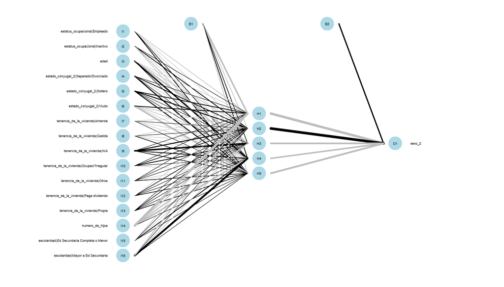

Figure 4a. Neural Network of Sex

```r
#sexo_casos_pendientes_3

mar <- par(mar =c(5.1, 4.1, 4.1, 2.1),mgp=c(3, 1, 0))

on.exit(par(mar = mar$mar))

plot(neuralnet_sex, plots = "net", custom=T,size = 9, pad_x = 0.8, nrobs = -1,cex_val = 3)
```

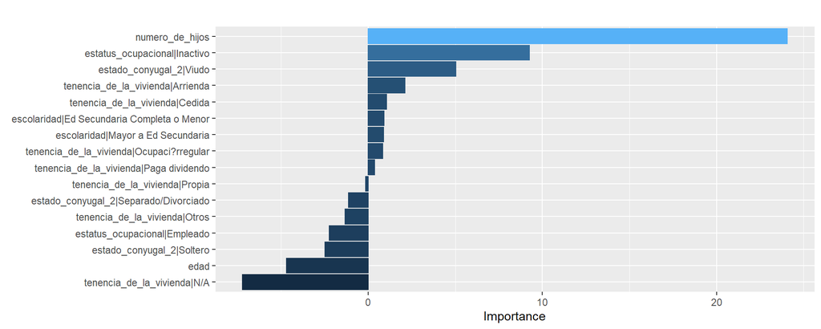

Figure 4b. Garson Plot of Variable Importance

```r
#sexo_casos_pendientes_3

mar <- par(mar = c(0, 0, 0, 0))

on.exit(par(mar = mar$mar))

plot(neuralnet_sex, plots = "olden", custom=T,size = 9, pad_x = 0.8, nrobs = -1,cex_val = 3)+
  ggtitle("")
```

```r
#sexo_casos_pendientes_3

  sex_replace_neuralnet <-
                  result_sex_all_cv_pred%>%
                     cbind(CONS_C1_df_dup_FEB_2020_prev24_test_nn[c("row","hash_key","sexo_2")])%>%
                    dplyr::select(row, hash_key, everything())%>%
                    as.data.frame()%>%
                    dplyr::mutate(sexo_2_corr= if_else(Prediction>=.5,"Mujer","Hombre",NA_character_))%>%
                    dplyr::arrange(hash_key)%>%
                    dplyr::group_by(hash_key)%>%
                    dplyr::mutate(sexo_2_corr2=lag(sexo_2_corr))%>%
                    dplyr::mutate(sexo_2_2=lag(sexo_2))%>%
                    dplyr::mutate(sexo_2_final=ifelse(sexo_2_2==sexo_2,sexo_2,NA_character_))%>%
                    dplyr::filter(!is.na(sexo_2_corr2))%>%
                    dplyr::mutate(Predicted_sex=ifelse(sexo_2_corr==sexo_2_corr2,sexo_2_corr,NA_character_))%>%
                    dplyr::filter(!is.na(Predicted_sex))%>%
                    dplyr::rename("Prediction_sex"="Prediction")


invisible(
    CONS_C1_df_dup_MAY_2020_prev0 %>%
        dplyr::filter(hash_key %in% as.character(as.vector(unlist(as.data.table(unlist(edad_ini_cons_misma_bd_2_casos_3[,"hash_key"])))))) %>%
        dplyr::filter(hash_key %in% c("014168e096787bf7e4c6951a3b4c27de","0110bb39c8fffafe0bbbe1fd17f51e71"))%>%
        dplyr::select(hash_key,ano_bd,edad_ini_cons,obs)
)

#21

#Misma bd, 2 casos
              CONS_C1_df_dup_MAY_2020_prev_2%>%
                  dplyr::left_join(sex_replace_neuralnet, by="hash_key",suffix=c("","_sexo_2_neuralnet")) %>%
                  dplyr::mutate(obs=case_when(!is.na(Predicted_sex)~glue::glue("{obs};3.03.1.XX.HASH w/ more than one distinct Sex.2 cases, same yearly dataset.Neural network imputation"),TRUE~obs))%>%
                  dplyr::mutate(sexo_2= ifelse(!is.na(Predicted_sex), as.character(sexo_2), as.character(sexo_2))) %>%
                  dplyr::select(-ends_with("_sexo_2_neuralnet"),-sexo_2_corr,-sexo_2_corr2,-sexo_2_2,-sexo_2_final) %>%
                  dplyr::mutate(sexo_2=as.factor(sexo_2))%>%
                  dplyr::select(-mean_edad_ini_cons,-n_edad_ini_cons_sus_prin_sus_prin_concat, -max_ano, -n_dis, -concat_hash_susini_edadinisusprin,-edad_al_ing_n_as,-edad_al_ing_less15,-Prediction_sex,-Predicted_sex)%>%
                  assign("CONS_C1_df_dup_MAY_2020_prev_3",., envir = .GlobalEnv)
#janitor::tabyl(sexo_2)

#CONS_C1_df_dup_FEB_2020_prev25 %>% group_by(hash_key) %>% dplyr::mutate(sexo_2_por_hash=n_distinct(sexo_2)) %>% ungroup() %>% dplyr::filter(sexo_2_por_hash>1) %>% nrow() %>%  formatC(, format="f", big.mark=",", digits=0)

#CONS_C1_df_dup_MAY_2020_prev_3 %>% dplyr::filter(grepl('3.03.1.', obs)) %>% dplyr::group_by(hash_key)
```

We replaced the value in sex with the imputed one in cases with two entries with different sexes. The imputed cases were restricted to users that both cases were imputed with the same sex (n=20).

#### 3.2.Ties and major differences in the age of onset of drug use

We used a neural network model to obtain valid ages of onset of drug use for 572 users that had more than one age of onset of drug use.

```r
#casos_fecha_inicio_cons_sus_prin_empates_3

#preparo la base de datos con los datos que me interesan
C1_edad_ini_cons_sus_not_ties<-
            CONS_C1_df_dup_MAY_2020_prev_3 %>%
            dplyr::filter(!hash_key %in% c(as.character(unlist(casos_fecha_inicio_cons_sus_empates_3["hash_key"]))))%>%
            dplyr::as_tibble()%>%
            janitor::clean_names()%>%
            dplyr::select(row, hash_key, edad_ini_cons, sus_ini, sus_principal,edad_al_ing,edad,ano_bd,edad_ini_sus_prin)%>%
           # sample_frac(.05)%>%
            na.omit()%>%
            dplyr::mutate(rn=row_number())

#_#_#_#_#_#_#_
#_#_#_#_#_#_#_
C1_edad_ini_cons_sus_ties<-
        CONS_C1_df_dup_MAY_2020_prev0 %>%
        dplyr::filter(hash_key %in% c(as.character(unlist(casos_fecha_inicio_cons_sus_empates_3["hash_key"]))))%>%
        dplyr::as_tibble()%>%
        janitor::clean_names()%>%
        dplyr::select(row, hash_key, edad_ini_cons, sus_ini, sus_principal,edad_al_ing,edad,ano_bd,edad_ini_sus_prin)%>%
        dplyr::arrange(hash_key)%>%
        dplyr::mutate(rn=row_number())

#_#_#_#_#_#_#_#_#_#_#_#_#_#_#_#_#_#_#_#_#_#_#_#_#_#_#_#_#_#_#_#_#_#_#_#_#_#_#_#_#_#_#_#_#_#_#_#_#_#_#_#_#_#_#_
#_#_#_#_#_#_#_#_#_#_#_#_#_#_#_#_#_#_#_#_#_#_#_#_#_#_#_#_#_#_#_#_#_#_#_#_#_#_#_#_#_#_#_#_#_#_#_#_#_#_#_#_#_#_#_

          #nn: Neural Networks using nnet
          #https://rdrr.io/cran/radiant.model/man/nn.html
          #https://radiant-rstats.github.io/radiant.model/reference/nn.html
          #https://radiant-rstats.github.io/docs/model/nn.html
          #result <- radiant::nn(C1_fech_nac_ties, "fech_nac", "edad:edad_inicio_sustancia_principal", type = "regression")
            result_edad_ini_cons_sus0<- nn(
              C1_edad_ini_cons_sus_not_ties,
              rvar = "edad_ini_cons", #The response variable in the model
              evar = c(
                "sus_ini", "sus_principal", "edad_al_ing", "edad",
                "ano_bd","edad_ini_sus_prin"
              ), #Explanatory variables in the model
              type = "regression", #Model type (i.e., "classification" or "regression")
              #lev= The level in the response variable defined as _success_
              #size= Number of units (nodes) in the hidden layer
              #decay=  Parameter decay
              #wts=  Weights to use in estimation
              #seed= Random seed to use as the starting point
              #check=  Optional estimation parameters ("standardize" is the default)
              #data_filter= Expression entered in, e.g., Data > View to filter the dataset in Radiant. The expression should be a string (e.g., "price > 10000")
              #form=   Optional formula to use instead of rvar and evar // Ocupar formula
              seed = 1245
            )
          #The model can be “tuned” by changing the Size (i.e., the number of nodes in the hidden layer)
            #and by adjusting the Decay rate. The higher the value set for Decay, the higher the penalty on
            #the size of (the sum of squares of) the weights. When Decay is set to 0, the model has the most
            #flexibility to fit the (training) data accurately. However, without Decay the model is also more
            #likely to overfit.

          #The best way to determine the optimal values for Size and Decays is to use Cross-Validation.
            #In radiant, you can use the cv.nn function for this purpose.

#_#_#_#_#_#_#_

            #cv.nn: Cross-validation for a Neural Network
            #https://radiant-rstats.github.io/radiant.model/reference/cv.nn.html
            #K= número de cv pasa para usar
            #repeats= cv repetido
            #decay= decaimiento en parámetros
            #size=número de nodos en la capa oculta
            #seed= semilla aleatoria como inicio
            #trace= imprimir progreso
            #fun= función para usar evaluación del modelo (auc para clasificación, RMSE para regresión; también está Rsq)
            #https://rdrr.io/cran/radiant.model/man/auc.html
            #https://rdrr.io/cran/radiant.model/man/RMSE.html
            #https://rdrr.io/cran/radiant.model/man/profit.html

            result_edad_ini_cons_all_cv<-
              cv.nn(result_edad_ini_cons_sus0, K= 10, decay = seq(0, 1, .5), size = 1:5, fun = RMSE, trace=T, seed=1245)
```

```
Working on size 1 decay 0
Working on size 1 decay 0.5
Working on size 1 decay 1
Working on size 2 decay 0
Working on size 2 decay 0.5
Working on size 2 decay 1
Working on size 3 decay 0
Working on size 3 decay 0.5
Working on size 3 decay 1
Working on size 4 decay 0
Working on size 4 decay 0.5
Working on size 4 decay 1
Working on size 5 decay 0
Working on size 5 decay 0.5
Working on size 5 decay 1
```

```r
            #cv.nn(result, decay = seq(0, 1, .5), size = 1:2, fun = profit, cost = 1, margin = 5)
            #30 minutos se demora en sacar size 1:4 con 4 fragmentos en decay

            #selecciono los parámetros que permitan hacer la mejor estimación
            nn_edad_ini_cons_par<-
              result_edad_ini_cons_all_cv[which(result_edad_ini_cons_all_cv$`RMSE (mean)`==min(result_edad_ini_cons_all_cv$`RMSE (mean)`)),c("decay","size","RMSE (mean)")]

#_#_#_#_#_#_#_
#Modelo final
            result_edad_ini_cons_sus<- nn(
                                      C1_edad_ini_cons_sus_not_ties,
                                      rvar = "edad_ini_cons",
                                      evar = c(
                                        "sus_ini", "sus_principal", "edad_al_ing", "edad","ano_bd","edad_ini_sus_prin"
                                      ),
                                      type = "regression",
                                      decay= as.numeric(nn_edad_ini_cons_par[1]),
                                      size= as.numeric(nn_edad_ini_cons_par[2]),
                                      seed = 1245
            )
            #33 MINUTOS DURA

#_#_#_#_#_#_#_
#PREDICT

            #https://radiant-rstats.github.io/radiant.model/reference/predict.nn.html
            #pred_data= Provide the dataframe to generate predictions (e.g., diamonds). The dataset must contain all columns used in the estimation
            #pred_cmd= Generate predictions using a command. For example, `pclass = levels(pclass)` would produce predictions
              #for the different levels of factor `pclass`. To add another variable, create a vector of prediction strings,
              #(e.g., c('pclass = levels(pclass)', 'age = seq(0,100,20)')
              #dec=  Number of decimals to show
              #envir= Environment to extract data from

                      #debemos eliminar los NAs
no_es=1
  if (no_es==0){
              print(paste0("comprobar si se reemplazó los valores perdidos por un 0.",
                    "Independiente de ello, si los lleno, al final los casos hacen un match perfecto a futuro"))
              C1_edad_ini_cons_sus_ties[!complete.cases(C1_edad_ini_cons_sus_ties[, c("sus_ini", "sus_principal", "edad_al_ing", "edad","ano_bd","edad_ini_sus_prin")]),
                               c("sus_ini", "sus_principal", "edad_al_ing", "edad","ano_bd","edad_ini_sus_prin")]
          }

#na.omit, sin variables na.
  result_edad_ini_cons_sus_cv_pred<- predict(result_edad_ini_cons_sus, pred_data = na.omit(C1_edad_ini_cons_sus_ties))
```

To obtain valid ages, we predicted the age of onset of drug use. We generated a total of 10 cross-validations, with alternatives of 1 to 5 layers, and a threshold of 0, .5 and 1 in every model (10x5x3). The model that obtained the best fit (RMSE (mean)= 2.88) had a size of 5 hidden layers, and a threshold for weights of 0.5 (L2 penalty).

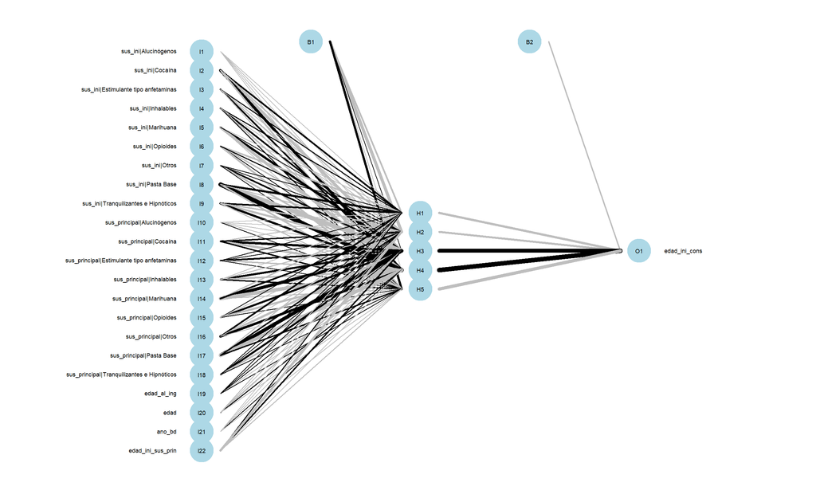

Figure 5a. Neural Network of Age of Onset of Drug Use

```r
mar <- par(mar = c(0, 0, 0, 0))

on.exit(par(mar = mar$mar))

plot(result_edad_ini_cons_sus, plots = "net", custom=T,size = 9, pad_x = 0.8, nrobs = -1,cex_val = 3)
```

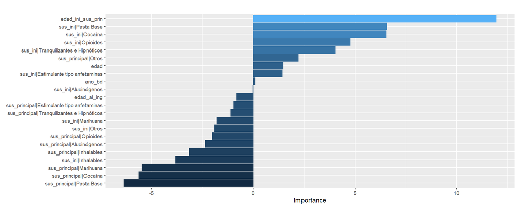

Figure 5b. Garson Plot of Variable Importance, Age of Onset of Drug Use

```r
#https://rdrr.io/cran/radiant.model/man/plot.nn.html

  #Options are "olden" or "garson" for importance plots, or "net" to depict the network structure
  #custom es para modificarlo con ggplot2

  #neural network as a neural interpretation diagram
  #f the sign of the weights switches after passing the hidden layer

mar <- par(mar = c(0, 0, 0, 0))

on.exit(par(mar = mar$mar))

plot(result_edad_ini_cons_sus, plots = "olden", custom=T,size = 9, pad_x = 0.8, nrobs = -1,cex_val = 3)+
  ggtitle("")
```

```r
#result_edad_ini_cons_sus_cv_pred
#na.omit(C1_edad_ini_cons_sus_ties)

age_onset_drug_use_replace_neuralnet_prev <-
                  result_edad_ini_cons_sus_cv_pred%>%
                     cbind(na.omit(C1_edad_ini_cons_sus_ties)[c("row","hash_key","edad_ini_cons")])%>%
                    dplyr::select(row, hash_key, everything())%>%
                    as.data.frame()%>%
                    dplyr::arrange(hash_key)%>%
                    dplyr::group_by(hash_key)%>%
                    dplyr::mutate(edad_ini_cons_2=lag(edad_ini_cons), edad_ini_sus_prin_2=lag(edad_ini_sus_prin), n_hash=n(), rn=row_number(), mean_pr= mean(Prediction))%>%
    janitor::clean_names()%>%
                    dplyr::filter(n_hash>1)%>% #De  1,463 [572] a 1,450 [559]
                    dplyr::ungroup()%>%
                    dplyr::mutate(diff_mean=abs(edad_ini_cons-mean_pr))%>% #es la diferencia absoluta entre la edad d einicio de consumo y el promedio predicho. EL que tiene menor cantidad, es el que selecciono.p
                    dplyr::group_by(hash_key)%>%
                    dplyr::slice(which.min(diff_mean)) %>%
                    #dplyr::filter(diff_mean==min(diff_mean))%>%
                    dplyr::rename("Prediction_age_onset_dr_use"="prediction")


#SACAR CASOS INVALIDOS PORQUE LA EDAD DE INICIO DE CONSUMO DE SUSTANCIAS, SUSTANCIA PRINCIPAL,
#  TERMINA SIENDO MENOR A LA EDAD DE INICIO DE CONSUMO A IMPUTAR

invalid_users_imputed_age_onset <-
              CONS_C1_df_dup_MAY_2020_prev_3%>%
                              dplyr::left_join(age_onset_drug_use_replace_neuralnet_prev[,c("hash_key", "edad_ini_cons")], by="hash_key",suffix=c("","_age_of_onset_drug_use_neuralnet")) %>%
                              dplyr::filter(!is.na(edad_ini_cons_age_of_onset_drug_use_neuralnet))%>%
                              dplyr::mutate(edad_ini_cons_age_onset=ifelse(edad_ini_cons_age_of_onset_drug_use_neuralnet>edad_ini_sus_prin,1,0))%>%
                              dplyr::group_by(hash_key)%>%
                              dplyr::mutate(sum_inalid_imputed_age=sum(edad_ini_cons_age_onset))%>%
                              dplyr::ungroup()%>%
                              dplyr::filter(sum_inalid_imputed_age>0)%>%
                              dplyr::arrange(hash_key)%>%
              dplyr::select(hash_key,edad_ini_cons_age_of_onset_drug_use_neuralnet,edad_ini_sus_prin,sum_inalid_imputed_age)%>%
  group_by(hash_key)



age_onset_drug_use_replace_neuralnet <-
                    age_onset_drug_use_replace_neuralnet_prev %>%
  dplyr::filter(!hash_key %in% as.character(unlist(invalid_users_imputed_age_onset["hash_key"])))

#21

#Misma bd, 2 casos
              CONS_C1_df_dup_MAY_2020_prev_3%>%
                  dplyr::left_join(age_onset_drug_use_replace_neuralnet[,c("hash_key", "edad_ini_cons","edad_ini_sus_prin")], by="hash_key",suffix=c("","_age_of_onset_drug_use_neuralnet")) %>%
                  dplyr::mutate(obs=case_when(!is.na(edad_ini_cons_age_of_onset_drug_use_neuralnet)~glue::glue("{obs};3.03.2.XX.HASH w/ more than one distinct Age of Onset Drug Use.Neural network imputation of ties"),TRUE~obs))%>%

                  dplyr::mutate(edad_ini_cons= ifelse(!is.na(edad_ini_cons_age_of_onset_drug_use_neuralnet), as.integer(edad_ini_cons_age_of_onset_drug_use_neuralnet),  as.integer(edad_ini_cons))) %>%

                  dplyr::select(-ends_with("_age_of_onset_drug_use_neuralnet")) %>%

                  dplyr::mutate(edad_ini_cons= as.integer(edad_ini_cons))%>%
                  dplyr::mutate(edad_ini_sus_prin= as.integer(edad_ini_sus_prin))%>%
                  assign("CONS_C1_df_dup_MAY_2020_prev_4",., envir = .GlobalEnv)
#janitor::tabyl(sexo_2)

#CONS_C1_df_dup_FEB_2020_prev25 %>% group_by(hash_key) %>% dplyr::mutate(sexo_2_por_hash=n_distinct(sexo_2)) %>% ungroup() %>% dplyr::filter(sexo_2_por_hash>1) %>% nrow() %>%  formatC(, format="f", big.mark=",", digits=0)

#CONS_C1_df_dup_MAY_2020_prev_4 %>% dplyr::filter(grepl('3.03.2.', obs)) %>% dplyr::group_by(hash_key)
```

We selected the age of onset of drug use of cases within users that had the same amount of different values in the age of onset of drug use. We also extended this selection to the age of onset of drug use in the primary (users=488).

#### 3.3.Ties and major differences in age of onset of drug use of primary substance

```r
#casos_fecha_inicio_cons_sus_prin_empates_3

age_onset_drug_use_replace_neuralnet_for_concat<-
            age_onset_drug_use_replace_neuralnet %>%
              dplyr::mutate(concat_hash_sus_prin=paste0(hash_key,"_",sus_principal))

#preparo la base de datos con los datos que me interesan
C1_edad_ini_cons_sus_prin_not_ties<-
            CONS_C1_df_dup_MAY_2020_prev_4 %>%
            dplyr::filter(!concat_hash_sus_prin %in% c(as.character(unlist(casos_fecha_inicio_cons_sus_prin_empates_3["concat_hash_sus_prin"]))))%>%
  #"_"_
  #SACO LOS CASOS QUE TIENEN QUE VER CON LA IMPUTACION ANTERIOR
            dplyr::filter(!concat_hash_sus_prin %in% c(as.character(unlist(age_onset_drug_use_replace_neuralnet_for_concat["concat_hash_sus_prin"]))))%>%
            dplyr::as_tibble()%>%
            janitor::clean_names()%>%
            dplyr::select(row, concat_hash_sus_prin, hash_key, edad_ini_cons, sus_ini, sus_principal, edad_al_ing, edad, ano_bd, edad_ini_sus_prin)%>%
           # sample_frac(.05)%>%
            na.omit()%>%
            dplyr::mutate(rn=row_number())

#_#_#_#_#_#_#_
#_#_#_#_#_#_#_
C1_edad_ini_cons_sus_prin_ties<-
        CONS_C1_df_dup_MAY_2020_prev %>%
        dplyr::mutate(concat_hash_sus_prin=paste0(hash_key,"_",sus_principal)) %>%
        dplyr::filter(concat_hash_sus_prin %in% c(as.character(unlist(casos_fecha_inicio_cons_sus_prin_empates_3["concat_hash_sus_prin"]))))%>%
    #SACO LOS CASOS QUE TIENEN QUE VER CON LA IMPUTACION ANTERIOR
            dplyr::filter(!concat_hash_sus_prin %in% c(as.character(unlist(age_onset_drug_use_replace_neuralnet_for_concat["concat_hash_sus_prin"]))))%>%
        dplyr::as_tibble()%>%
        janitor::clean_names()%>%
        dplyr::select(row, concat_hash_sus_prin, hash_key, edad_ini_cons, sus_ini, sus_principal, edad_al_ing, edad, ano_bd, edad_ini_sus_prin)%>%
        dplyr::arrange(concat_hash_sus_prin)%>%
        dplyr::mutate(rn=row_number())

#_#_#_#_#_#_#_#_#_#_#_#_#_#_#_#_#_#_#_#_#_#_#_#_#_#_#_#_#_#_#_#_#_#_#_#_#_#_#_#_#_#_#_#_#_#_#_#_#_#_#_#_#_#_#_
#_#_#_#_#_#_#_#_#_#_#_#_#_#_#_#_#_#_#_#_#_#_#_#_#_#_#_#_#_#_#_#_#_#_#_#_#_#_#_#_#_#_#_#_#_#_#_#_#_#_#_#_#_#_#_

          #nn: Neural Networks using nnet
          #https://rdrr.io/cran/radiant.model/man/nn.html
          #https://radiant-rstats.github.io/radiant.model/reference/nn.html
          #https://radiant-rstats.github.io/docs/model/nn.html
          #result <- radiant::nn(C1_fech_nac_ties, "fech_nac", "edad:edad_inicio_sustancia_principal", type = "regression")
            result_edad_ini_cons_sus_prin0<- nn(
              C1_edad_ini_cons_sus_prin_not_ties,
              rvar = "edad_ini_sus_prin", #The response variable in the model
              evar = c(
                "sus_ini", "sus_principal", "edad_al_ing", "edad",
                "ano_bd","edad_ini_cons"
              ), #Explanatory variables in the model
              type = "regression", #Model type (i.e., "classification" or "regression")
              #lev= The level in the response variable defined as _success_
              #size= Number of units (nodes) in the hidden layer
              #decay=  Parameter decay
              #wts=  Weights to use in estimation
              #seed= Random seed to use as the starting point
              #check=  Optional estimation parameters ("standardize" is the default)
              #data_filter= Expression entered in, e.g., Data > View to filter the dataset in Radiant. The expression should be a string (e.g., "price > 10000")
              #form=   Optional formula to use instead of rvar and evar // Ocupar formula
              seed = 1245
            )
          #The model can be “tuned” by changing the Size (i.e., the number of nodes in the hidden layer)
            #and by adjusting the Decay rate. The higher the value set for Decay, the higher the penalty on
            #the size of (the sum of squares of) the weights. When Decay is set to 0, the model has the most
            #flexibility to fit the (training) data accurately. However, without Decay the model is also more
            #likely to overfit.

          #The best way to determine the optimal values for Size and Decays is to use Cross-Validation.
            #In radiant, you can use the cv.nn function for this purpose.

#_#_#_#_#_#_#_

            #cv.nn: Cross-validation for a Neural Network
            #https://radiant-rstats.github.io/radiant.model/reference/cv.nn.html
            #K= número de cv pasa para usar
            #repeats= cv repetido
            #decay= decaimiento en parámetros
            #size=número de nodos en la capa oculta
            #seed= semilla aleatoria como inicio
            #trace= imprimir progreso
            #fun= función para usar evaluación del modelo (auc para clasificación, RMSE para regresión; también está Rsq)
            #https://rdrr.io/cran/radiant.model/man/auc.html
            #https://rdrr.io/cran/radiant.model/man/RMSE.html
            #https://rdrr.io/cran/radiant.model/man/profit.html

            result_edad_ini_cons_susprin_all_cv<-
              cv.nn(result_edad_ini_cons_sus_prin0, K= 10, decay = seq(0, 1, .5), size = 1:5, fun = RMSE, trace=T, seed=1245)
```

```
Working on size 1 decay 0
Working on size 1 decay 0.5
Working on size 1 decay 1
Working on size 2 decay 0
Working on size 2 decay 0.5
Working on size 2 decay 1
Working on size 3 decay 0
Working on size 3 decay 0.5
Working on size 3 decay 1
Working on size 4 decay 0
Working on size 4 decay 0.5
Working on size 4 decay 1
Working on size 5 decay 0
Working on size 5 decay 0.5
Working on size 5 decay 1
```

```r
            #cv.nn(result, decay = seq(0, 1, .5), size = 1:2, fun = profit, cost = 1, margin = 5)
            #30 minutos se demora en sacar size 1:4 con 4 fragmentos en decay

            #selecciono los parámetros que permitan hacer la mejor estimación
    nn_edad_ini_cons_sus_prin_par<-
              result_edad_ini_cons_susprin_all_cv[which(result_edad_ini_cons_susprin_all_cv$`RMSE (mean)`==min(result_edad_ini_cons_susprin_all_cv$`RMSE (mean)`)),c("decay","size","RMSE (mean)")]

#_#_#_#_#_#_#_
#Modelo final
            result_edad_ini_cons_sus_prin<- nn(
                                      C1_edad_ini_cons_sus_prin_not_ties,
                                      rvar = "edad_ini_sus_prin",
                                      evar = c(
                                        "sus_ini", "sus_principal", "edad_al_ing", "edad","ano_bd","edad_ini_cons"
                                      ),
                                      type = "regression",
                                      decay= as.numeric(nn_edad_ini_cons_sus_prin_par[1]),
                                      size= as.numeric(nn_edad_ini_cons_sus_prin_par[2]),
                                      seed = 1245
            )
            #33 MINUTOS DURA

#_#_#_#_#_#_#_
#PREDICT
            #https://radiant-rstats.github.io/radiant.model/reference/predict.nn.html
            #pred_data= Provide the dataframe to generate predictions (e.g., diamonds). The dataset must contain all columns used in the estimation
            #pred_cmd= Generate predictions using a command. For example, `pclass = levels(pclass)` would produce predictions
              #for the different levels of factor `pclass`. To add another variable, create a vector of prediction strings,
              #(e.g., c('pclass = levels(pclass)', 'age = seq(0,100,20)')
              #dec=  Number of decimals to show
              #envir= Environment to extract data from

                      #debemos eliminar los NAs
no_es=1
  if (no_es==0){
              print(paste0("comprobar si se reemplazó los valores perdidos por un 0.",
                    "Independiente de ello, si los lleno, al final los casos hacen un match perfecto a futuro"))
              C1_edad_ini_cons_sus_ties[!complete.cases(C1_edad_ini_cons_sus_ties[, c("sus_ini", "sus_principal", "edad_al_ing", "edad","ano_bd","edad_ini_sus_prin")]),
                               c("sus_ini", "sus_principal", "edad_al_ing", "edad","ano_bd","edad_ini_sus_prin")]
          }

#na.omit, sin variables na.
  result_edad_ini_cons_sus_prin_cv_pred<- predict(result_edad_ini_cons_sus_prin,
                                                  pred_data = na.omit(C1_edad_ini_cons_sus_prin_ties))
```

To obtain valid ages, we predicted the age of onset of drug use. We generated a total of 10 cross-validations, with alternatives of 1 to 5 layers, and a threshold of 0, .5 and 1 in every model (10x5x3). The model that obtained the best fit (RMSE (mean)= 4.63) had a size of 5 hidden layers, and a threshold for weights of 0.5 (L2 penalty).

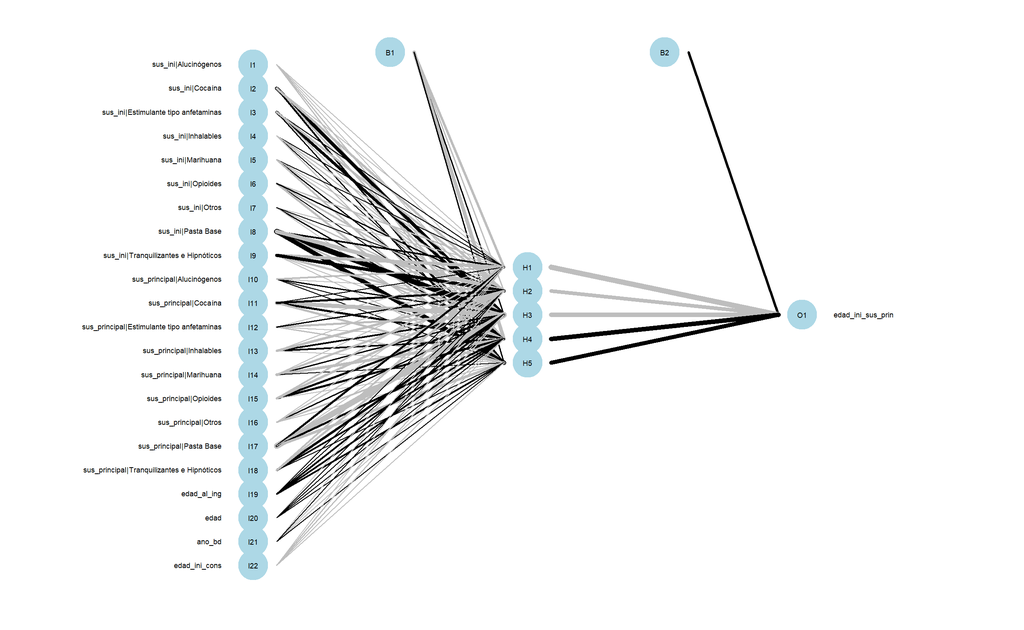

Figure 6a. Neural Network of Age of Onset of Drug Use

```r
mar <- par(mar = c(0, 0, 0, 0))

on.exit(par(mar = mar$mar))

plot(result_edad_ini_cons_sus_prin, plots = "net", custom=T,size = 9, pad_x = 0.8, nrobs = -1,cex_val = 3)
```

[figure not shown]

Figure 6b. Garson Plot of Variable Importance, Age of Onset of Drug Use

```r
#https://rdrr.io/cran/radiant.model/man/plot.nn.html

  #Options are "olden" or "garson" for importance plots, or "net" to depict the network structure
  #custom es para modificarlo con ggplot2

  #neural network as a neural interpretation diagram
  #f the sign of the weights switches after passing the hidden layer

mar <- par(mar = c(0, 0, 0, 0))

on.exit(par(mar = mar$mar))

plot(result_edad_ini_cons_sus, plots = "olden", custom=T,size = 9, pad_x = 0.8, nrobs = -1,cex_val = 3)+
  ggtitle("")
```

```r
#result_edad_ini_cons_sus_prin_cv_pred
#na.omit(C1_edad_ini_cons_sus_prin_ties)

age_onset_drug_use_prim_subs_replace_neuralnet_prev <-
                  result_edad_ini_cons_sus_prin_cv_pred%>%
                     cbind(na.omit(C1_edad_ini_cons_sus_prin_ties)[c("row","hash_key","concat_hash_sus_prin","edad_ini_sus_prin")])%>%
                    dplyr::select(row, hash_key, everything())%>%
                    as.data.frame()%>%
                    dplyr::arrange(concat_hash_sus_prin)%>%
                    dplyr::group_by(concat_hash_sus_prin)%>%
                    dplyr::mutate(n_concat_hash=n(), rn=row_number(), mean_pr= mean(Prediction))%>%
    janitor::clean_names()%>%
                    dplyr::filter(n_concat_hash>1)%>% #De  795  [316] a 795 [316]
                    dplyr::ungroup()%>%
                    dplyr::mutate(diff_mean=abs(edad_ini_sus_prin-mean_pr))%>% #es la diferencia absoluta entre la edad d einicio de consumo sus prin y el promedio predicho. EL que tiene menor cantidad, es el que selecciono.p
                    dplyr::group_by(concat_hash_sus_prin)%>%
                    dplyr::slice(which.min(diff_mean)) %>%
                    #dplyr::filter(diff_mean==min(diff_mean))%>%
                    dplyr::rename("Prediction_age_onset_dr_use_prim_subs"="prediction")


#CONS_C1_df_dup_MAY_2020_prev_4 %>%  dplyr::filter(concat_hash_sus_prin %in% as.character(unlist(na.omit(C1_edad_ini_cons_sus_prin_ties["concat_hash_sus_prin"]))))%>% group_by(concat_hash_sus_prin)


#SACAR CASOS INVALIDOS PORQUE LA EDAD DE INICIO DE CONSUMO DE SUSTANCIAS, SUSTANCIA PRINCIPAL,
#  TERMINA SIENDO MENOR A LA EDAD DE INICIO DE CONSUMO A IMPUTAR

invalid_users_imputed_age_onset_prim_subs <-
              CONS_C1_df_dup_MAY_2020_prev_4%>%
                              dplyr::left_join(age_onset_drug_use_prim_subs_replace_neuralnet_prev[,c("concat_hash_sus_prin", "edad_ini_sus_prin")], by="concat_hash_sus_prin",suffix=c("","_age_of_onset_drug_use_neuralnet")) %>% # glimpse()
                              dplyr::filter(!is.na(edad_ini_sus_prin_age_of_onset_drug_use_neuralnet))%>%
                              dplyr::mutate(edad_ini_sus_prin_age_onset_prim_subs=ifelse(edad_ini_sus_prin_age_of_onset_drug_use_neuralnet<edad_ini_cons,1,0))%>%
                              dplyr::group_by(concat_hash_sus_prin)%>%
                              dplyr::mutate(sum_inalid_imputed_age=sum(edad_ini_sus_prin_age_onset_prim_subs))%>%
                              dplyr::ungroup()%>%
                              dplyr::filter(sum_inalid_imputed_age>0)%>%
                              dplyr::arrange(concat_hash_sus_prin)%>%
              dplyr::select(concat_hash_sus_prin,edad_ini_sus_prin_age_of_onset_drug_use_neuralnet,edad_ini_cons,sum_inalid_imputed_age)%>%
  group_by(concat_hash_sus_prin)

#PARA VER CÓMO VOY
#CONS_C1_df_dup_MAY_2020_prev_4 %>% dplyr::filter(concat_hash_sus_prin=="01ade496577825c5d26c96df19531e9f_Pasta Base") %>% dplyr::select(hash_key, sus_principal, edad_ini_cons, edad_ini_sus_prin)

#NO ME VA A CALZAR, PORQUE EN UNA BASE ANTERIOR (PREV A SOLAS DE MAYO), ESTA COMBINACION DE USUARIO CON SUS PRIN TENIA DISTINTAS FECHAS, QUE ESTÁN YA RESUELTAS AHORA


age_onset_drug_use_prim_subs_replace_neuralnet <-
                    age_onset_drug_use_prim_subs_replace_neuralnet_prev %>%
  dplyr::filter(!concat_hash_sus_prin %in% as.character(unlist(invalid_users_imputed_age_onset_prim_subs["concat_hash_sus_prin"])))%>%
  #se supone que ya los descarté de un principio, pero por si acaso
  dplyr::filter(!concat_hash_sus_prin %in% as.character(unlist(age_onset_drug_use_replace_neuralnet_for_concat["concat_hash_sus_prin"])))

#21

#Misma bd, 2 casos
              CONS_C1_df_dup_MAY_2020_prev_4%>%
                  dplyr::left_join(age_onset_drug_use_prim_subs_replace_neuralnet[,c("concat_hash_sus_prin","edad_ini_sus_prin")], by="concat_hash_sus_prin",suffix=c("","_age_of_onset_drug_use_prim_subs_neuralnet")) %>%
                  dplyr::mutate(obs=case_when(!is.na(edad_ini_sus_prin_age_of_onset_drug_use_prim_subs_neuralnet)~glue::glue("{obs};3.03.3.XX.HASH w/ more than one distinct Age of Onset Drug Use Primary Substance.Neural network imputation of ties"),TRUE~obs))%>%

                  dplyr::mutate(edad_ini_sus_prin= ifelse(!is.na(edad_ini_sus_prin_age_of_onset_drug_use_prim_subs_neuralnet), as.integer(edad_ini_sus_prin_age_of_onset_drug_use_prim_subs_neuralnet),  as.integer(edad_ini_sus_prin))) %>%

                  dplyr::select(-ends_with("_age_of_onset_drug_use_prim_subs_neuralnet")) %>%

                  dplyr::mutate(edad_ini_sus_prin= as.integer(edad_ini_sus_prin))%>%
                  assign("CONS_C1_df_dup_MAY_2020_prev_5",., envir = .GlobalEnv)
#janitor::tabyl(sexo_2)

#CONS_C1_df_dup_FEB_2020_prev25 %>% group_by(hash_key) %>% dplyr::mutate(sexo_2_por_hash=n_distinct(sexo_2)) %>% ungroup() %>% dplyr::filter(sexo_2_por_hash>1) %>% nrow() %>%  formatC(, format="f", big.mark=",", digits=0)

#CONS_C1_df_dup_MAY_2020_prev_5 %>% dplyr::filter(grepl('3.03.3.XX.', obs)) %>% dplyr::group_by(hash_key)
#800 casos y 311 usuarios, 316 combinaciones
```

### 4.Exploration of spaces between treatments

At this point, it is necessary to differentiate between intermediate treatment events (referrals, changes in the treatment center, among others) and different treatments. ** But what would be a suitable cut point?**, that is why we explored the amount of days between each entry in users that had more than one treatment.

```r
CONS_C1_df_dup_MAY_2020_prev_5_exp_spaces<-
      CONS_C1_df_dup_MAY_2020_prev_5 %>%
          dplyr::group_by(hash_key) %>%
          dplyr::mutate(fech_ing_num_may20=as.numeric(as.Date(fech_ing))) %>%
          dplyr::mutate(fech_egres_num_may20=as.numeric(as.Date(fech_egres_imp))) %>%
          dplyr::mutate(fech_egres_num_may20=ifelse(is.na(fech_egres_imp),18213,fech_egres_num_may20)) %>% #equivalente a 2019-11-13
          dplyr::mutate(fech_ing_next_treat=dplyr::lag(fech_ing_num_may20)) %>%
          dplyr::mutate(diff_bet_treat=fech_ing_next_treat-fech_egres_num_may20)%>%
          dplyr::filter(!is.na(dias_trat_imp))%>%
          #dplyr::select(hash_key,fech_ing,fech_ing_num_may20,fech_egres_imp, fech_egres_num_may20,dias_trat_imp,fech_ing_next_treat,diff_bet_treat)
          dplyr::select(row,hash_key,fech_ing,fech_egres_imp, dias_trat_imp,diff_bet_treat,motivodeegreso_imp,motivodeegreso_mod_imp,id_centro)


knitr::kable(cbind(data.frame(psych::describe(CONS_C1_df_dup_MAY_2020_prev_5_exp_spaces$diff_bet_treat)),t(quantile(CONS_C1_df_dup_MAY_2020_prev_5_exp_spaces$diff_bet_treat,c(.10,.25,.5,.75,.9),na.rm=T))),
            format = "html", format.args = list(decimal.mark = ".", big.mark = ","),
            caption="Table 5. Summary Table for Difference Between Treatments",
            align =rep('c', 101))  %>%
        kableExtra::kable_styling(bootstrap_options = c("striped", "hover"),font_size = 8) %>%
        kableExtra::scroll_box(width = "100%", height = "150px")
```

Table 5. Summary Table for Difference Between Treatments

|  | vars | n | mean | sd | median | trimmed | mad | min | max | range | skew | kurtosis | se | 10% | 25% | 50% | 75% | 90% |
| --- | --- | --- | --- | --- | --- | --- | --- | --- | --- | --- | --- | --- | --- | --- | --- | --- | --- | --- |
| X1 | 1 | 31,666 | 434.2109 | 574.459 | 199 | 315.3459 | 292.0722 | 0 | 3,464 | 3,464 | 1.897949 | 3.695736 | 3.228215 | 1 | 19 | 199 | 623 | 1,244 |

```r
#117,387
#85,722 unique hash key
# 109,268 = 8119 fechas de egreso perdidas
#
#quantile(CONS_C1_df_dup_MAY_2020_prev_2_exp_spaces$diff_bet_treat,c(seq(1,100)/100),na.rm=T)
quantiles_diff_bet_treat<-data.table::data.table(cbind(quantile(CONS_C1_df_dup_MAY_2020_prev_5_exp_spaces$diff_bet_treat,c(seq(1,100)/100),na.rm=T)),keep.rownames = T)
#117387-31665


#diff_bet_treat= siempre es la diferencia con el siguiente tratmaiento
```

Considering the distribution of differences in days between each entry, we defined the cutpoint in 30 days, which represented the 28% of the total differences .(n= 31,666).